# StatComp Homework

Hanlu Zhang

2023-12-04

# HW0

## 作业内容与思路

作业内容：使用**Knit**生成至少3个例子，每个例子应当图（表）文并茂。最好还有数学公式。

思路：选择四个统计学方法为本次作业的例子，由易到难分别是相关系数、两样本t检验、回归分析、树模型。这些例子既能以公式的形式解释数学原理，也能通过精致的图表来展示结果。使用的数据集为**R**自带的**mpg**数据集。

```r
data(mpg)
mydata = mpg[,c('displ','year','cyl','cty','hwy')]
summary(mydata)
```

```
##      displ            year           cyl             cty             hwy
##  Min.   :1.600   Min.   :1999   Min.   :4.000   Min.   : 9.00   Min.   :12.00
##  1st Qu.:2.400   1st Qu.:1999   1st Qu.:4.000   1st Qu.:14.00   1st Qu.:18.00
##  Median :3.300   Median :2004   Median :6.000   Median :17.00   Median :24.00
##  Mean   :3.472   Mean   :2004   Mean   :5.889   Mean   :16.86   Mean   :23.44
##  3rd Qu.:4.600   3rd Qu.:2008   3rd Qu.:8.000   3rd Qu.:19.00   3rd Qu.:27.00
##  Max.   :7.000   Max.   :2008   Max.   :8.000   Max.   :35.00   Max.   :44.00
```

## 汽车变量的相关性分析

我们计算各指标的Pearson相关系数。指标$X$和指标$Y$的Pearson相关系数的计算公式如下：
$$\rho=\dfrac{Cov(X,Y)}{\sqrt{Var(X)Var(Y)}}.$$

```r
cor(mydata, method = c("pearson"))
```

```
##            displ         year        cyl         cty          hwy
## displ  1.0000000  0.147842816  0.9302271 -0.79852397 -0.766020021
## year   0.1478428  1.000000000  0.1222453 -0.03723229  0.002157643
## cyl    0.9302271  0.122245347  1.0000000 -0.80577141 -0.761912354
## cty   -0.7985240 -0.037232291 -0.8057714  1.00000000  0.955915914
## hwy   -0.7660200  0.002157643 -0.7619124  0.95591591  1.000000000
```

cty和hwy的相关系数最高。 说明城市燃油率和高速燃油率之间高度线性相关。

## 汽车变量的假设检验

**mpg**数据集包含了1999年的数据与2008年的数据。我们以年份为分组指标，用两样本t检验的方法比较两年的发动机排量是否有显著差异。记两组样本分别为$x_1,x_2,\cdots,x_m$，来自正态总体$N(\mu_1,\sigma_1^2)$，$y_1,y_2,\cdots,y_n$，来自正态总体$N(\mu_2,\sigma_2^2)$。t统计量的计算公式如下：
$$t = \dfrac{\bar x-\bar
y}{s_w\sqrt{\dfrac{1}{m}+\dfrac{1}{n}}}.$$

其中，$s_w=(\dfrac{1}{m+n-2}(\sum\limits_{i=1}^m(x_i-\bar x)^2+\sum\limits_{i=1}^n(y_i-\bar y)^2))^{\frac{1}{2}}$.

t检验的P值<0.05，认为1999年的发动机排量与2008年的有显著差异。由计算的均值可知，2008年的发动机排量更高。

```r
mydata$year <- as.factor(mydata$year)
t.test(displ~year, mydata, var.equal=T)
```

```
##
##  Two Sample t-test
##
## data:  displ by year
## t = -2.2769, df = 232, p-value = 0.0237
## alternative hypothesis: true difference in means between group 1999 and group 2008 is not equal to 0
## 95 percent confidence interval:
##  -0.71105335 -0.05133981
## sample estimates:
## mean in group 1999 mean in group 2008
##           3.281197           3.662393
```

## 汽车变量的线性回归分析

我们用多元线性模型，探究发动机排量和气缸数量对高速燃油率的影响。以displ和cyl为自变量，hwy为响应变量，拟合如下线性模型：
$$hwy =
\beta_0+\beta_1·displ+\beta_2·cyl.$$

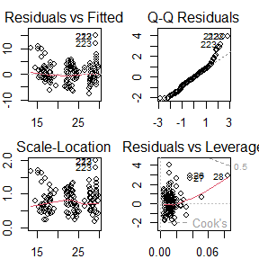

```r
lm_model = lm(hwy~displ+cyl, mydata)
par(mfrow=c(2,2), mar = c(2, 2, 2, 2))
plot(lm_model)
```

拟合的线性模型结果为$hwy = 38.2162-1.9599·displ-1.3537·cyl$。模型调整后的$R^2$为0.6014414，从残差图可以看出，模型达到了较好的拟合效果。

## 汽车变量的决策树模型

我们选用决策树模型探究displ、year、cyl、cty四个变量中，哪个变量对hwy的影响最大。决策树的算法是以特征（变量）的信息增益为基础的。给定数据集$D$和特征$A$，信息增益$g(D,A)$的计算公式如下：
$$g(D,A) = H(D) - H(D|A).$$

其中，$H(D)$是数据集$D$的经验熵，$H(D)=-\sum\limits_{k=1}^K\dfrac{|C_k|}{|D|}\log_2\dfrac{|C_k|}{|D|}$。$H(D|A)$是特征$A$对数据集$D$的经验条件熵，$H(D|A)=\sum\limits_{i=1}^n\dfrac{|D_i|}{|D|}H(D_i)$。

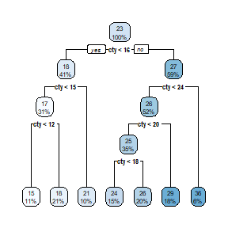

```r
tree_model = rpart(hwy~., data = mydata)
rpart.plot(tree_model)
```

根据信息增益结果，绘制树状图。由图像可以看出，模型中最重要的指标是城市燃油率（cty），它对高速燃油率影响最大。

# HW1

## 第一题

*问题描述：*标准拉普拉斯分布的密度函数是$f(x)=\frac{1}{2}e^{-|x|},~x\in R$。用inverse transform method生成1000个服从该分布的随机样本，再用一种方法来比较生成的样本和目标分布。

*思路：* （1）inverse transform method生成随机样本：计算累计密度函数，求逆分布函数，生成$U(0,1)$分布随机数，将随机数代入逆分布函数； （2）生成目标分布：采用**R**中的`rlaplace()`函数； （3）用直方图来比较生成样本和目标分布。

首先计算标准拉普拉斯分布的累计密度函数，由累计密度函数的定义：
$$F(x) = \int _{-\infty}^x f(u)du = \int
_{-\infty}^x \dfrac{1}{2}e^{-|u|} du,$$
$$when~x>0,~F(x) = \int _{-\infty}^0
\dfrac{1}{2}e^{u} du + \int _{0}^x \dfrac{1}{2}e^{-u} du =
1-\dfrac{1}{2}e^{-x},$$
$$when~x\leq
0,~F(x) = \int _{-\infty}^x \dfrac{1}{2}e^{u} du = \dfrac{1}{2}e^{x}.$$
因此，$F(x) = \dfrac{1}{2}[1+sign(x)(1-e^{-|x|})]$，其中，$sign(x)$是符号函数，$x>0$时，$sign(x)=1$；$x=0$时，$sign(x)=0$；$x<0$时，$sign(x)=-1$；。

令$u=F(x)$，解得标准拉普拉斯分布的逆分布函数为：
$$F^{-1}(u)=sign(\dfrac{1}{2}-u)\ln
(1-2|u-\dfrac{1}{2}|).$$
本题的**R**代码如下：

```r
set.seed(1)
n = 1000
u = runif(n)
generate_sample = sign(0.5-u)*log(1-2*abs(u-0.5))
```

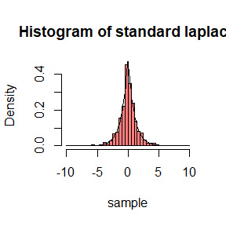

```r
# 绘制图像
hist(generate_sample, breaks=30, xlim=c(-10,10), prob=TRUE,
     col=rgb(1,0,0,0.5), xlab="sample", ylab="Density",
     main = "Histogram of standard laplace")
y = seq(-10, 10, 0.1)
lines(y, 0.5*exp(-abs(y)))
```

图像上红色部分是用逆变换法生成的样本的直方图，黑色曲线是目标分布的概率密度曲线。通过比较可以看出，逆变换法生成的样本分布很接近目标分布。然而，通过`hist`函数的`main`参数的`expression`生成直方图标题中的公式时，`e^{-|x|}`语法报错，尚未得到解决，因此直方图为文字标题。

*参考资料：* （1）https://search.r-project.org/CRAN/refmans/VGAM/html/laplaceUC.html

## 第二题

*问题描述：*写一个函数，用acceptance-rejection method来生成服从分布$Beta(a,b)$的$n$个随机样本。生成服从分布$Beta(3,2)$的1000个随机样本。画出生成的样本的直方图，并在上面叠加理论$Beta(3,2)$的密度。

*思路：* （1）先找到$Beta(a,b)$的概率密度函数的包络函数$g(t)$，推导随机变量$x$被接受的条件； （2）多次循环，得到指定size的$Beta(a,b)$样本。

$Beta(a,b)$的概率密度函数为：
$$f(x) =
\dfrac{\Gamma(a+b)}{\Gamma(a)\Gamma(b)}x^{a-1}(1-x)^{b-1},~0<x<1.$$
其中，$\Gamma(x+1)=x!$。

令$g(x)$为均匀分布$U(0,1)$的概率密度函数，则$\forall x\in(0,1),~f(x)/g(x)\leq \dfrac{\Gamma(a)\Gamma(b)}{\Gamma(a+b)}$，因此$f(x)/g(x)$的上界$c=\dfrac{\Gamma(a)\Gamma(b)}{\Gamma(a+b)}$。那么，来自$g(x)$的随机变量$x$被接受的条件是：
$$\dfrac{f(x)}{cg(x)}=\dfrac{\dfrac{\Gamma(a+b)}{\Gamma(a)\Gamma(b)}x^{a-1}(1-x)^{b-1}}{\dfrac{\Gamma(a+b)}{\Gamma(a)\Gamma(b)}·1}=x^{a-1}(1-x)^{b-1}>u,$$
其中，$u$为均匀分布$U(0,1)$的随机变量。

用acceptance-rejection method来生成服从分布$Beta(a,b)$的$n$个随机样本的**R**函数如下，其中$a,b$分别为$Beta(a,b)$的参数，`n`为样本size：

```r
set.seed(1)

generate_beta = function(a, b, n){
  k = 0 # counter for accept
  j = 0 # iterations
  beta_sample = numeric(n)
  while (k < n) {
    u = runif(1) # upper bound
    j = j + 1
    x = runif(1) # r.v. from g
    if (x^(a-1)*(1-x)^(b-1)>u){
      # accept x
      k = k + 1
      beta_sample[k] = x
    }
  }
  return(beta_sample)
}
```

用自定义函数`generate_beta`生成服从分布$Beta(3,2)$的1000个随机样本，画出样本直方图，并在图上叠加理论$Beta(3,2)$的密度曲线。

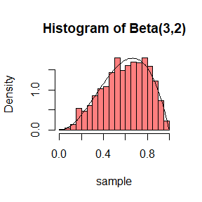

```r
# 生成
a = 3
b = 2
Beta_Sample = generate_beta(a,b,1000)

# 画图
hist(Beta_Sample, breaks=30, xlim=c(0,1), prob=TRUE, col=rgb(1,0,0,0.5), xlab="sample",
     ylab="Density", main = "Histogram of Beta(3,2)")
y = seq(0, 1, 0.01)
lines( y, factorial(a+b-1)/(factorial(a-1)*factorial(b-1)) * y^(a-1) * (1-y)^(b-1) )
```

图像上红色部分是用acceptance-rejection method生成的$Beta(3,2)$样本的直方图，随机样本的size为1000。此时，生成的样本分布很接近目标分布，但峰值还略有差别，真实分布的峰值更靠右。

## 第三题

*问题描述：* rescaled Epanechnikov kernel 是一个对称密度函数：$f_e(x) = \dfrac{3}{4}(1-x^2),~|x|\leq 1$。Devroye & Gyorfi给出了如下算法来模拟这一分布：生成服从均匀分布$U(-1,1)$的三类独立同分布样本，分别记作$U_1,~U_2,~U_3$；如果$|U_3|\geq|U_2|$并且$|U_3|\geq|U_1|$，产生$U_2$，否则产生$U_3$。写出一个函数，生成来自$f_e$的随机变量，并绘制大型模拟随机样本的密度直方图。

*思路：* （1）以样本size作为函数的循环参数，以比较式作为循环条件，产生样本； （2）绘制样本的直方图。

用Devroye & Gyorfi给出的算法生成服从分布$f_e(x)$的样本的**R**函数如下，其中，`n`为样本size：

```r
set.seed(1)

generate_fe = function(n){
  k = 0 # counter for accept
  j = 0 # iterations
  fe_sample = numeric(n)
  while (k < n) {
    u1 = runif(1, min = -1, max = 1)
    u2 = runif(1, -1, 1)
    u3 = runif(1, -1, 1)
    k = k + 1
    j = j + 1
    if ( abs(u3)>=abs(u2) & abs(u3)>=abs(u1) ){
      # accept u2
      fe_sample[k] = u2
    }else{
      fe_sample[k] = u3
    }
  }
  return(fe_sample)
}
```

用自定义函数`generate_fe`生成服从分布$f_e(x)$的10000个随机样本（认为10000是large size），并画出样本直方图。

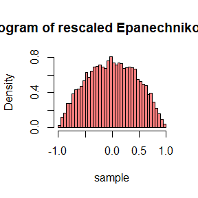

```r
fe_Sample = generate_fe(10000)

hist(fe_Sample, breaks=30, prob=TRUE, col=rgb(1,0,0,0.5), xlab="sample",
     ylab="Density", main = "Histogram of rescaled Epanechnikov kernel")
```

图像上红色部分是用Devroye & Gyorfi给出的算法生成的rescaled Epanechnikov kernel样本的直方图，随机样本的size为10000。从直方图可以看出，该密度函数是对称的。

## 第四题

*问题描述：* 证明第三题中的算法可以生成服从$f_e(x)$概率密度函数的随机数。

*思路：*要证明生成的随机数的概率密度函数是rescaled Epanechnikov kernel，只需证生成的随机数的分布函数与$f_e(x)$的分布函数相同即可。

首先计算$f_e(x)$的分布函数：
$$F_e(x) = \int _{-1}^x\dfrac{3}{4}(1-u^2)du =
-\dfrac{1}{4}x^3+\dfrac{3}{4}x+\dfrac{1}{2},~|x|<1.$$
接下来，计算生成的随机数$U$的分布函数：
$$F_U(k) = P(U\leq k)$$
$$= P(U_2\leq k|U=U_2)P(U=U_2)+P(U_3\leq
k|U=U_3)P(U=U_3)$$
$$= P(U_2\leq
k,~U=U_2)+P(U_3\leq k,~U=U_3).$$
此外，注意到$U_1,~U_2,~U_3$独立同分布，因此有：
$$f(u_1,u_2,u_3)=f(u_1)f(u_2)f(u_3)=\dfrac{1}{8}.$$

分情况讨论，先考虑$-1<k<0$：

（1）$U=U_2$的条件是：$|U_3|\geq|U_2|$并且$|U_3|\geq|U_1|$，此时$-1<U_2<k<0$。若$U_3>0$，则有$-U_3\leq U_1 \leq U_3$；若$U_3\leq 0$，则有$U_3\leq U_1 \leq -U_3$。因此：
$$P(U_2\leq k,~U=U_2)=\int_{-1}^k \int_{-U_2}^1
\int_{-U_3}^{U_3}f(u_1)f(u_2)f(u_3)du_1du_3du_2$$
$$+ \int_{-1}^k \int_{-1}^{U_2}
\int_{U_3}^{-U_3}f(u_1)f(u_2)f(u_3)du_1du_3du_2$$
$$=-\dfrac{1}{12}k^3+\dfrac{1}{4}k+\dfrac{1}{6}.$$
（2）$U=U_3$的条件是：$|U_3|<|U_2|$并且$|U_3|<|U_1|$，或$|U_3|\geq|U_2|$并且$|U_3|<|U_1|$，或$|U_3|<|U_2|$并且$|U_3|\geq|U_1|$。此时$-1<U_3<k<0$。注意到$|U_1|,~|U_2|,~|U_3|$独立且均服从均匀分布$U(0,1)$。在之后的积分式中，将绝对值变换后的变量、密度函数用$^*$标记。
$$P(U_2\leq k,~U=U_2)=\int_{-1}^k \int_{-U_3}^1
\int_{-U_3}^{1}f^*(u_1^*)f^*(u_2^*)f(u_3)du_1^*du_2^*du_3$$
$$+\int_{-1}^k \int_{0}^{-U_3}
\int_{-U_3}^{1}f^*(u_1^*)f^*(u_2^*)f(u_3)du_1^*du_2^*du_3$$
$$+\int_{-1}^k \int_{-U_3}^{1} \int_{0}^{-U_3}
f^*(u_1^*)f^*(u_2^*)f(u_3)du_1^*du_2^*du_3$$
$$=-\dfrac{1}{6}k^3+\dfrac{1}{2}k+\dfrac{1}{3}.$$
其中，$f^*(u_1^*)f^*(u_2^*)f(u_3)=\dfrac{1}{2}$.

因此，当$-1<k<0$时，
$$F_U(k) =
(-\dfrac{1}{12}k^3+\dfrac{1}{4}k+\dfrac{1}{6})+(-\dfrac{1}{6}k^3+\dfrac{1}{2}k+\dfrac{1}{3})=-\dfrac{1}{4}k^3+\dfrac{3}{4}k+\dfrac{1}{2}.$$
同理，当$0\leq k<1$时，也有
$$F_U(k)
=-\dfrac{1}{4}k^3+\dfrac{3}{4}k+\dfrac{1}{2}.$$
综上所述，我们证得了$F_e(x)=F_U(x),~|x|<1$，所以第三题中的算法可以生成服从$f_e(x)$概率密度函数的随机数。

## 复现sample函数

*问题描述：* 用逆变换法复现函数`sample`在参数`replace=TRUE`时的功能。

*思路：*（1）函数参数应当包含抽样总体`x`，样本size`n`，抽样概率`prob`，以及随机种子`seed`；（2）`sample`函数在参数`replace=TRUE`时是有放回的随机抽样，相当于从离散总体中生成随机数，逆变换法步骤为：a.生成均匀分布随机数$u\sim U(0,1)$，b.输入随机变量$X$的分布$F$，如果$F(x_{i-1})\leq u<F(x_{i})$，则输出$X=x_i$。

**R**函数的参数含义分别为：`x`是抽样总体，需要使用者输入一个长度$\geq 1$的向量；参数`n`是样本size，默认为抽样总体的总数；参数`prob`是抽样概率，默认为等概率。

```r
my_sample = function(x, n = length(x), prob = rep(1/length(x), length(x))){
  cp = cumsum(prob)
  u = runif(n)
  random_sample = x[findInterval(u,cp)+1]
  return(random_sample)
}
```

下面是用`my_sample`函数生成随机数的例子，与`sample`函数的结果进行比较。

**例1：在0-1总体中等概率抽样10个样本。** 指定`my_sample`和`sample`两个函数的抽样总体和样本size。抽样概率是默认值$0.5,0.5$，是有放回等概率抽样。

```r
set.seed(1)
x = c(0,1)
n = 10
s = sample(x, n, replace = TRUE)
ms = my_sample(x, n)
print(s)
```

```
##  [1] 0 1 0 0 1 0 0 0 1 1
```

```r
print(ms)
```

```
##  [1] 0 0 1 0 1 0 1 1 0 1
```

**例2：对英文字母进行重排。** 指定`my_sample`和`sample`两个函数的抽样总体为`letters`。样本size是默认值，为抽样总体的总数。抽样概率是默认值，每一个字母抽中的概率是$1/26$，是有放回等概率抽样。

```r
set.seed(2)
x = letters
s = sample(x,replace = TRUE)
ms = my_sample(x)
print(s)
```

```
##  [1] "u" "o" "f" "f" "h" "q" "q" "l" "i" "r" "k" "a" "c" "v" "p" "r" "s" "w" "h"
## [20] "g" "a" "v" "i" "p" "d" "k"
```

```r
print(ms)
```

```
##  [1] "e" "v" "w" "n" "q" "v" "h" "r" "d" "z" "h" "c" "e" "y" "u" "z" "j" "n" "v"
## [20] "a" "a" "r" "y" "h" "v" "u"
```

**例3：在1、2、3总体中不等概率抽样100个样本。** 指定`my_sample`和`sample`两个函数的抽样总体、样本size为100、抽样概率为$0.2, 0.3, 0.5$，是有放回不等概率抽样。

```r
set.seed(3)
x = c(1:3)
n = 100
prob = c(0.2, 0.3, 0.5)
s = sample(x, n, prob, replace = TRUE)
ms = my_sample(x, n, prob)
count_sample <- as.vector(table(s))
count_my_sample <- as.vector(table(ms))
print(count_sample)
```

```
## [1] 20 29 51
```

```r
print(count_my_sample)
```

```
## [1] 21 32 47
```

从以上三个例子的结果可以看出，`my_sample`函数能够实现`sample`在参数`replace=TRUE`时的功能。虽然结果有细微差别，但当样本size足够大时，抽样结果更加接近。

# HW2

## 第一题

*问题描述：*（1）在Buffon’s niddle experiment中，找一个最优的$\dfrac{l}{d}=\rho$，使得$\hat \pi=\dfrac{2l}{d\hat p}$的渐近方差最小，其中$\hat p=\dfrac{m}{n}$（提示：使用$\delta$法，$m\sim B(n,p)$）。记最优的$\rho$为$\rho_{\min}$。（2）取三个不同的$\rho$值（$0\leq\rho\leq1$，包含$\rho_{\min}$），用MC方法比较计算出的$\hat \pi$的方差，以验证上一题的结论。（$n=10^6,~K=100$）

*思路：*（1）用delta法写出$\hat \pi$的表达式，该表达式和$\rho$有关，再求最小值。（2）取$\rho_1=\rho_{\min}=1,\rho_2=0.8,\rho_3=0.5$，用MC方法生成$\hat \pi$，再计算方差。

解：已知$m\sim B(n,p)$，$\hat \pi=\dfrac{2l}{d\hat p}=\dfrac{2ln}{dm}$。由delta法：
$$Var(\hat
\pi)=\dfrac{4\rho^2(1-p)}{np^3}.$$
注意到$p=\dfrac{2\rho}{\pi}$，代入到上式：
$$Var(\hat
\pi)=\dfrac{4\rho^2(1-\dfrac{2\rho}{\pi})}{n(\dfrac{2\rho}{\pi})^3}=\dfrac{\pi^2}{n}(\dfrac{\pi}{2\rho}-1).$$
由于$0\leq\rho\leq1$，因此$\rho=1$时$\hat \pi$的渐近方差最小。$\rho_{\min}=1$，$Var(\hat \pi)_{\min}=\dfrac{\pi^2(\pi-2)}{2n}.$

分别取$\rho_1=1,\rho_2=0.8,\rho_3=0.5$，线段间距$d$设置为2，对应的针长$l$分别是$2,~1.6,~1$。$\hat \pi$的估计式为：
$$\hat \pi=
\dfrac{2l}{d}\dfrac{n}{I(\frac{l}{2}\sin(Y)>X)},$$
其中，$Y\sim U(0,\pi/2)$，$X\sim U(0,d/2)$。用MC方法进行模拟，计算$\hat \pi$及其方差的代码如下：

```r
n = 1e6
K = 100
l = c(2, 1.6, 1)
d = 2
pihat = data.frame(matrix(NA, K, 3))

for (i in 1:3) {
  for (j in 1:K){
    set.seed(j)
    X = runif(n,0,d/2)
    Y = runif(n,0,pi/2)
    pihat[j,i] = 2*l[i]/d/mean(l[i]/2*sin(Y)>X)
  }
}
```

```r
# 计算方差
var = apply(pihat, 2, var)
```

[output not shown]

## 第二题

*问题描述：*例5.7说明了求解蒙特卡洛积分的控制变量法：
$$\theta = \int_0^1e^xdx.$$
现考虑对偶变量法，计算$Cov(e^U,e^{1-U})$以及$Var(e^U+e^{1-U})$，其中$U\sim Uniform(0,1)$。与简单MC方法相比，对偶法能降低百分之多少的方差？

*思路：*分别用简单MC方法和对偶变量法计算$\hat \theta$及其方差，并计算方差降低的百分比。

解：在简单MC方法中，有$\theta = E[g(U)]$，其中$g(U)=e^U$，$U\sim U(0,1)$。 考虑对偶变量，$e^{1-U}$与$e^U$负相关且同分布：
$$Cov(e^U, e^{1-U}) =
E[e^Ue^{1-U}]-E[e^U]E[e^{1-U}]$$
$$=
e-(e-1)(e-1)$$
$$=
-e^2+3e-1.$$
将$Cov(e^U, e^{1-U})$代入到方差计算式中：
$$Var(e^U+e^{1-U}) = Var(e^U) + Var(e^{1-U}) +
2Cov(e^U, e^{1-U})$$
$$=
\dfrac{1}{2}(-e^2+4e-3)\times 2 + 2\times(-e^2+3e-1)$$
$$= -3e^2+10e-5.$$
而$Var(e^U)=\dfrac{1}{2}(-e^2+4e-3)$，计算方差降低的百分比：
$$\dfrac{Var(e^U)-\dfrac{1}{2}Var(e^U+e^{1-U})}{Var(e^U)}=\dfrac{\dfrac{1}{2}(-e^2+4e-3)-\dfrac{1}{2}(-3e^2+10e-5)}{\dfrac{1}{2}(-e^2+4e-3)}$$
$$=\dfrac{(-e^2+4e-3)-(-3e^2+10e-5)}{-e^2+4e-3}$$
$$=\dfrac{2e^2-6e+2}{-e^2+4e-3}$$
$$\approx 0.9677.$$
与简单MC方法相比，对偶法能降低约96.77%的方差。

## 第三题

*问题描述：*参考上一题，分别用对偶变量法和简单MC法估计$\theta$。计算使用对偶法带来的方差减少百分比的经验估计，将结果与上一题中的理论值进行比较。

*思路：*首先生成0-1区间上均匀分布的随机数，计算$e^U$与$e^{1-U}$的值，分别用对偶变量法和简单MC法估计$\theta$。再计算两种方法的方差，以及方差降低的百分比。

解：我们首先将对偶变量法和简单MC法的生成随机数机制写成函数`MC_anti`。然后进行100次模拟，每次生成10000个随机数，用于估计$\theta$。**R**代码如下：

```r
# 函数参数：生成的随机数数量，是否要用对偶变量法
# 函数功能：如果要用对偶变量法，1/2的随机数要做变换；否则不用做变换，即简单MC法
MC_anti = function(n, antithetic = TRUE){
  u = runif(n/2, 0, 1)
  if(!antithetic) v = runif(n/2, 0, 1) else
    v = 1 - u
  u = c(u, v)
  theta = mean(exp(u))
  theta
}

# 开始计算theta及其方差
K = 100
n = 10000
theta_simple = theta_anti = numeric(K)
for (i in 1:K) {
  set.seed(i)
  theta_simple[i] = MC_anti(n, antithetic = FALSE)
  theta_anti[i] = MC_anti(n, antithetic = TRUE)
}
var_simple = var(theta_simple)
var_anti = var(theta_anti)
print(var_simple)
```

```
## [1] 2.061706e-05
```

```r
print(var_anti)
```

```
## [1] 5.645978e-07
```

```r
print((var_simple-var_anti)/var_simple)
```

```
## [1] 0.972615
```

与简单MC方法相比，对偶法带来的方差减少的经验估计值为97.26%。该结果比上一题的理论值（96.77%）略高，这可能是由模拟的随机性所导致的。

# HW3

## 第一题

*问题描述：* 在Stratified Sampling问题中，记区间$I$被分割为$(a_i,b_i),~i=1,...k$，简单估计的方差为$Var(\hat{\theta^M})$，分层估计的方差为$Var(\hat{\theta^S})$，且
$$Var(\hat{\theta^M}) =
\dfrac{1}{Mk}\sum_{i=1}^k\sigma_i^2+\dfrac{1}{M}Var(\theta_I) =
Var(\hat{\theta^S})+\dfrac{1}{M}Var(\theta_I).$$
证明：若$g$是$(a,b)$上的连续函数，当$\forall i \in \{1,...k\},~b_i-a_i\rightarrow 0$，$Var(\hat{\theta^S})/Var(\hat{\theta^M})\rightarrow 0$.

*思路：* 按照$Var(\hat{\theta^M})$与$Var(\hat{\theta^S})$之间的关系式化简$Var(\hat{\theta^S})/Var(\hat{\theta^M})\rightarrow 0$，将问题转化为对$\dfrac{1}{Mk}\sum_{i=1}^k\sigma_i^2$的分析。再根据定义写出$\dfrac{1}{Mk}\sum_{i=1}^k\sigma_i^2$的表达式，将积分内部放大为与$u$无关的项，从而利用$b_i-a_i\rightarrow 0$的条件证明。

*证明：* 由$Var(\hat{\theta^M}) = \dfrac{1}{Mk}\sum_{i=1}^k\sigma_i^2+Var(\theta_I) = Var(\hat{\theta^S})+Var(\theta_I)$知，
$$\dfrac{Var(\hat{\theta^S})}{Var(\hat{\theta^M})}
=
\dfrac{\frac{1}{Mk}\sum_{i=1}^k\sigma_i^2}{\frac{1}{Mk}\sum_{i=1}^k\sigma_i^2+Var(\theta_I)}$$
$$=
\dfrac{1}{1+\dfrac{\frac{1}{M}Var(\theta_I)}{\frac{1}{Mk}\sum_{i=1}^k\sigma_i^2}}$$
$$=
\dfrac{1}{1+\dfrac{Var(\theta_I)}{\frac{1}{k}\sum_{i=1}^k\sigma_i^2}}.$$
由于$b_i-a_i\rightarrow 0$时，$\theta_i\rightarrow g(U)$。而$g$是连续函数，因此$Var(\theta_I)\rightarrow Var( g(U))<\infty$，所以接下来只需证$\frac{1}{k}\sum_{i=1}^k\sigma_i^2\rightarrow 0$即可。

根据$\sigma_i^2$的定义，有：
$$\frac{1}{k}\sum_{i=1}^k\sigma_i^2 =
\frac{1}{k}\sum_{i=1}^k\int_{a_i}^{b_i}\dfrac{1}{b_i-a_i}(g(u)-\bar{g(u)})^2du$$
记$\Delta g_i = g_{\max}(u)-g_{\min}(u),~u\in[a_i,b_i]$，显然有$(g(u)-\bar{g(u)})^2<(\Delta g_i)^2$。所以：
$$\frac{1}{k}\sum_{i=1}^k\sigma_i^2 <
\frac{1}{k}\sum_{i=1}^k\int_{a_i}^{b_i}\dfrac{1}{b_i-a_i}(\Delta
g_i)^2du$$
$$=
\frac{1}{k}\sum_{i=1}^k(b_i-a_i)\dfrac{1}{b_i-a_i}(\Delta
g_i)^2,$$
$$\leq
\frac{1}{k}\sum_{i=1}^k(b_i-a_i)\dfrac{1}{b_i-a_i}\max(\Delta
g_i)^2,$$
又由于$g(x)$是连续的，因此$b_i-a_i\rightarrow 0$时，$\max(\Delta g_i)^2\rightarrow 0$。从而有：
$$\frac{1}{k}\sum_{i=1}^k\sigma_i^2
\rightarrow 0.$$
至此，我们证得，当$b_i-a_i\rightarrow 0$时：
$$\dfrac{Var(\hat{\theta^S})}{Var(\hat{\theta^M})}
=
\dfrac{\frac{1}{Mk}\sum_{i=1}^k\sigma_i^2}{\frac{1}{Mk}\sum_{i=1}^k\sigma_i^2+Var(\theta_I)}\rightarrow
0.$$

## 第二题

*问题描述：* 找到以$(1,\infty)$为支撑并且“接近”$g(x)$的两个importance functions $f_1$和$f_2$，
$$g(x)=\dfrac{x^2}{\sqrt{2\pi}}e^{-x^2/2},~x>1.$$
其中哪个function能够在用importance sampling方法估计$\int_1^{\infty}g(x)dx$的时候有更小的方差？解释原因。

*思路：* importance function是易于生成，并且与$g(x)$有较高的相关性（最好比值接近于常数）的密度函数。按照该思路构造$f$，在支撑集上，$f$与$g(x)$的比值越接近常数，其方差越小。

*解：* 以$(1,\infty)$为支撑的两个importance functions如下所示，它们在$(1,\infty)$上积分值为1，符合密度函数的定义：
$$f_1(x) = e^{-(x-1)},~x>1,$$
$$f_2(x) = \dfrac{1}{2}x^{-3/2 },~x>1.$$
其中，$f_1(x)$在用importance sampling方法估计$\int_1^{\infty}g(x)dx$的时候有更小的方差。下面分别从理论和数值模拟两个方面进行说明：

（1） 理论推导： 设$x$的概率密度函数为$f(x)$，则积分值
$$\theta = \int_1^{\infty}g(x)dx =
\int_1^{\infty}\dfrac{g(x)}{f(x)}f(x)dx =
E[\dfrac{g(x)}{f(x)}],$$
从$X$的分布中生成$X_1,...X_n$个独立随机变量，积分的MC估计值为：
$$\hat \theta = \bar{g(X)}
=\dfrac{1}{n}\sum_{i=1}^n\dfrac{g(x)}{f(x)}.$$
由上式可知，$\dfrac{g(x)}{f(x)}$越接近常数，$\hat \theta$的方差越小。而$f_1(x) = e^{-(x-1)}$比$f_2(x) = \dfrac{1}{2}x^{-3/2 }$更满足这一点，因此$f_1$在用importance sampling方法估计$\int_1^{\infty}g(x)dx$的时候有更小的方差。

如图所示，图(A)分别是$g(x)$，$f_1(x)$，$f_2(x)$在$(1,6)$上的图像。图(B)分别是$g(x)/f_1(x)$，$g(x)/f_2(x)$在$(1,6)$上的图像。从图(B)可以看出，$\dfrac{g(x)}{f_1(x)}$更接近常数。

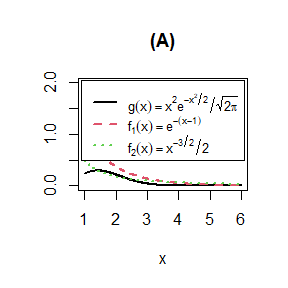

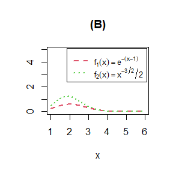

## 第三题

*问题描述：* 用importance sampling方法计算$\int_1^{\infty}\dfrac{x^2}{\sqrt{2\pi}}e^{-x^2/2}dx$的MC估计。

*解：* 积分的MC估计值为：
$$\hat
\theta = \bar{g(X)}
=\dfrac{1}{n}\sum_{i=1}^n\dfrac{g(x)}{f(x)}.$$
根据上一题的分析，我们选择importance functions：
$$f_(x) = e^{-(x-1)},~x>1,$$
计算的代码及结果如下：

```r
m <- 1e6
set.seed(123)
g <- function(x) {
  x^2 / sqrt(2*pi) * exp(-x^2/2) * (x > 1)
}
f1 <- function(x) {exp(-(x-1))* (x > 1)}

u = runif(m)
x = 1 - log(1-u)
est <- mean(g(x)/f1(x))
cat('g(x)的MC估计为：', est)
```

```
## g(x)的MC估计为： 0.4004642
```

## 第四题

*问题描述：* 计算例5.13的stratified importance sampling estimate，与例5.10的结果比较一下。

*思路：* 先将$x$的区间均匀分成五段，根据每一段区间上的importance function，计算区间上的积分值，然后相加得到最终结果。

*解：* 为估计积分值：
$$\theta =
\int_0^1\dfrac{e^{-x}}{1+x^2}dx,$$
我们选择的importance function为：
$$f(x) =
\dfrac{e^{-x}}{1-e^{-1}},~0<x<1.$$
将$(0,1)$区间均匀分成五段后，第$j$区间上的importance function为：
$$f_j(x) =
\dfrac{5e^{-x}}{1-e^{-1}},~\dfrac{j-1}{5}<x<\dfrac{j}{5}.$$
而积分的估计值为：
$$\hat{\theta}_{SI} =
\dfrac{1}{5}\sum_{j=1}^5\hat{\theta_j}.$$
stratified importance sampling计算积分估计值及标准差的代码及结果如下：

```r
m = 1000
theta_j = numeric(5)
theta_SI = numeric(10)
g = function(x){
  exp(-x - log(1+x^2))*(x<1)*(x>0)
}
for(i in 1:10){
  set.seed(i)
  theta_j[1] = mean(g(runif(m/5, 0, 0.2)))
  theta_j[2] = mean(g(runif(m/5, 0.2, 0.4)))
  theta_j[3] = mean(g(runif(m/5, 0.4, 0.6)))
  theta_j[4] = mean(g(runif(m/5, 0.6, 0.8)))
  theta_j[5] = mean(g(runif(m/5, 0.8, 1)))
  theta_SI[i] = mean(theta_j)
}
mu = mean(theta_SI)
sd = sd(theta_SI)

mu
```

```
## [1] 0.52468
```

```r
sd
```

```
## [1] 0.0009556493
```

例5.10的结果是$\hat{\theta} = 0.5258$，$sd(\hat{\theta})=0.0970$。与本题结果相比，积分的估计值接近，但本题的标准差小得多。

## 第五题

*问题描述：* 假设使用95%的对称t区间来估计均值，但样本数据是非正态的。那么置信区间覆盖均值的概率不一定等于0.95。使用蒙特卡罗实验估计样本容量$n=20$的$\chi^2(2)$数据随机样本的t区间覆盖概率。将t区间结果与例6.4中的模拟结果进行比较。

*思路：* 先生成20个服从$\chi^2(2)$的随机数，计算样本的t检验的置信区间，然后统计一下包含真实均值的区间数量，除以1000即要求解的t区间覆盖概率。

*解：* 我们将计算区间的方法写在函数`CI`中，并用`replicate`函数重复1000次计算。代码及结果如下：

```r
n = 20
m = 1000
alpha = 0.05

CI = function(n, alpha) {
  x = rchisq(n, 2)
  upCL = mean(x) + sqrt(var(x)/n) * qt(1-alpha/2, n-1)
  lowCL = mean(x) - sqrt(var(x)/n) * qt(1-alpha/2, n-1)
  CL = c(upCL, lowCL)
  return (CL)
}
set.seed(123)
myCI = replicate(m, expr = CI(n, alpha))

prob = (mean(myCI[1,]<2)+mean(myCI[2,]>2))
cat('随机样本的t区间覆盖概率为：', 1-prob)
```

```
## 随机样本的t区间覆盖概率为： 0.908
```

当样本数据是非正态的时候，随机样本的t区间覆盖概率不再是$1-\alpha$，而是略小一些的值，在本题中是0.908。

而在Example 6.4中，当样本数据是正态的时候，方差区间覆盖概率接近$1-\alpha$，为0.956；当样本数据是非正态的时候，方差区间覆盖概率远小于$1-\alpha$，为0.773。这也说明了，对于偏离正态数据，t区间应该比方差的区间更稳健。

## 第六题

*问题描述：* 当抽样总体是非正态时，利用蒙特卡罗模拟研究t检验的经验1型错误率是否近似等于名义显著性水平$\alpha$。t检验对于轻微偏离正态是稳健的。讨论抽样总体为(i) $\chi^2(1)$、(ii) Uniform(0,2)和(iii) Exponential(1)的情况下的模拟结果。在每种情况下，检验$H_0:\mu =\mu_0~vs~H_1: \mu\neq\mu_0$，其中$\mu_0$分别为$\chi^2(1)$、Uniform(0,2)和Exponential(1)的均值。

*思路：* 每一个小题的思路都是类似的，生成n个服从某抽样总体分布的随机数，计算样本的t检验的P值（并据此做假设检验）及经验1型错误率。

*解：* 注意到$\chi^2(1)$、Uniform(0,2)和Exponential(1)的均值为1，因此在假设检验问题中，$\mu_0=1$。进行1000次试验，令$\alpha=0.05$，计算P值的均值以及经验1型错误率（P值小于名义显著性水平$\alpha$的概率）。代码及结果如下：

```r
m = 1000
alpha = 0.05
mu0 = 1
n = 20
p = matrix(0, 3, m)
p.hat = error = numeric(3)

for (j in 1:m) {
  set.seed(j)
  ttest1 = t.test(rchisq(n, 1), mu = mu0)
  ttest2 = t.test(runif(n, 0, 2), mu = mu0)
  ttest3 = t.test(rexp(n, 1), mu = mu0)
  p[1, j] = ttest1$p.value
  p[2, j] = ttest2$p.value
  p[3, j] = ttest3$p.value
}

for (i in 1:3) {
  p.hat[i] = mean(p[i,])
  error[i] = mean(p[i,]<alpha)
}
p.hat
```

```
## [1] 0.4804856 0.4991935 0.4813325
```

```r
error
```

```
## [1] 0.084 0.058 0.080
```

由P值的均值大于显著性水平，我们没有充足的理由拒绝$H_0: \mu = \mu_0$，因此认为三个非正态抽样总体的均值为1。但经验1型错误率并不近似等于名义显著性水平$\alpha$，均大于$\alpha$。

# HW4

## 第一题

*问题描述：* 考虑m=1000个假设，其中前95%个原假设成立，后5%个对立假设成立。在原假设之下，P值服从U(0,1)分布，在对立假设之下，P值服从Beta(0.1,1)分布（可用rbeta生成随机数）。基于`p.adjust`，应用Bonferroni校正与BH校正生成的m个独立的P值，从而得到校正后的P值，与$\alpha=0.1$比较确定是否拒绝原假设。基于M=1000次模拟，估计FWER、FDR、TPR，输出一个表格。

*思路：*在每一次模拟中，先按照不同假设下P值的分布生成m个P值，分别用两种校正方法计算校正后的P值，然后决定是否拒绝原假设。基于这一结果，再估计FWER、FDR、TPR。

FWER的计算方法为：
$$FWER =
P(\mbox{当}H_0\mbox{为真时，至少拒绝1个}H_0),$$

FDR的计算方法为：
$$FDR =
\dfrac{FP}{FP+TP} =
\dfrac{\mbox{拒绝的}H_0\mbox{的数量}|H_0\mbox{为真}}{\mbox{拒绝的}H_0\mbox{的数量}|H_0\mbox{为真}+\mbox{拒绝的}H_0\mbox{的数量}|H_1\mbox{为真}},$$

TPR的计算方法为（准确来说，“拒绝的$H_1$的数量”应当是“没有充分理由拒绝的$H_0$的数量”）：
$$TPR = \dfrac{TP}{TP+FN} =
\dfrac{\mbox{拒绝的}H_0\mbox{的数量}|H_1\mbox{为真}}{\mbox{拒绝的}H_0\mbox{的数量}|H_1\mbox{为真}+\mbox{拒绝的}H_1\mbox{的数量}|H_1\mbox{为真}},$$

以下是实现该流程的代码：

```r
M = 1000
m = 1000
alpha = 0.1

p_Bonf = p_BH = matrix(NA, M, m)
value_Bonf = value_BH = matrix(NA, M, 3)

for (i in 1:M) {
  set.seed(i)
  p_H0 = runif(0.95*m, 0, 1)
  p_H1 = rbeta(0.05*m, shape1 = 0.1, shape2 = 1)
  p = c(p_H0, p_H1)
  p_Bonf[i,] = p.adjust(p, method = 'bonferroni')
  p_BH[i,] = p.adjust(p, method = 'BH')
  # FWER
  value_Bonf[i, 1] = any(p_Bonf[i,1:950] < alpha)
  value_BH[i, 1] = any(p_BH[i,1:950] < alpha)
  # FDR
  value_Bonf[i, 2] = sum(p_Bonf[i, 1:950] < alpha) /
    (sum(p_Bonf[i, 1:950] < alpha) + sum(p_Bonf[i, 951:1000] < alpha))
  value_BH[i, 2] = sum(p_BH[i, 1:950] < alpha) /
    (sum(p_BH[i, 1:950] < alpha) + sum(p_BH[i, 951:1000] < alpha))
  # TPR
  value_Bonf[i, 3] = sum(p_Bonf[i, 951:1000] < alpha) /
    (sum(p_Bonf[i, 951:1000] < alpha) + sum(p_Bonf[i, 951:1000] >= alpha))
  value_BH[i, 3] = sum(p_BH[i, 951:1000] < alpha) /
    (sum(p_BH[i, 951:1000] < alpha) + sum(p_BH[i, 951:1000] >= alpha))
}
```

最后，我们将结果输出成表格：

```r
value = rbind(colMeans(value_Bonf), colMeans(value_BH))
colnames(value) = c('FWER', 'FDR', 'TPR')
rownames(value) = c('Bonferroni', 'B-H')
knitr::kable(round(value, 3), format = "latex",align='c')
```

[output not shown]

## 第二题

*问题描述：* 假设$X\sim Exp(\lambda)$，则$\lambda$的MLE为$\hat{\lambda}=1/\bar X$。这并不是一个无偏估计，$E\hat{\lambda} = n\lambda/(n-1)$，$sd(\hat{\lambda}) = n\lambda/[(n-1)\sqrt{n-2}]$。参数要求如下：

- 真实值$\lambda = 2$，
- 样本量$n = 5, 10, 20$，
- Bootstrap的重复次数$B=1000$，
- 模拟的重复次数$m=1000$，

比较mean bootstrap bias，bootstrap standard error与理论值，将结果输出成一个表格。

*思路：* 首先生成n个$Exp(2)$的随机数，按照参数的估计式，在每一次模拟中，重复B次Bootstrap，计算Bootstrap estimates of bias and standard error。最后计算estimates的均值，与理论值比较。

*解：* 编写一个函数，输入为样本量n，进行1000次模拟，每次模拟进行1000次Bootstrap，输出Bootstrap estimates与理论值。代码如下：

```r
lambda_bootstrap = function(n){
  # 理论值
  bias_the = 2*n/(n-1) - 2
  sd_the = 2*n/((n-1)*sqrt(n-2))

  m = 1000
  B = 1000
  bias = sd = numeric(m)
  for (i in 1:m) {
    x = rexp(n, 2)
    set.seed(i)
    lambda_star = numeric(B)
    # 采样值
    for (b in 1:B) {
      xstar = sample(x, replace = TRUE)
      lambda_star[b] = 1 / mean(xstar)
    }
    bias[i] = mean(lambda_star) - 1 / mean(x)
    sd[i] = sd(lambda_star)
  }
  value = c(mean(bias), bias_the, mean(sd), sd_the)
  return(value)
}
```

分别计算样本量$n = 5, 10, 20$时的mean bootstrap bias，bootstrap standard error与相应的理论值：

```r
value = rbind(lambda_bootstrap(5),lambda_bootstrap(10),lambda_bootstrap(20))
colnames(value) = c('Bias-bootstrap', 'Bias-theory', 'Sd-bootstrap', 'Sd-theory')
rownames(value) = c('n=5', 'n=10', 'n=20')
knitr::kable(round(value, 3), format = "latex",align='c')
```

[output not shown]

## 第三题

*问题描述：* 计算例7.2 correlation statistic的t置信区间的bootstrap估计.

*思路：* 进行B次bootstrap，每一次中都基于采样得到的样本计算correlation statistic，并且进行R次bootstrap来计算统计量的标准差。在实际编程中，可以将correlation statistic的计算编写成一个函数方便调用。

*解：* 假设$x = (x_1,...x_n)$是观测到的样本，则$100(1-\alpha)\%$bootstrap t confidence interval是：
$$(\hat{\theta}-t^*_{1-\alpha/2}\hat{se}(\hat{\theta}),~
\hat{\theta}-t^*_{\alpha/2}\hat{se}(\hat{\theta})),$$
其中，$\hat{\theta}$是基于观测样本直接计算出的correlation statistic，$\hat{se}(\hat{\theta})$ 是$\hat{\theta}$的标准差估计值。在第$b$次bootstrap中，记$t^{(b)}=\dfrac{\hat{\theta}^{(b)}-\hat{\theta}}{\hat{se}(\hat{\theta}^{(b)})}$，其中$\hat{se}(\hat{\theta}^{(b)})$是再次用bootstrap方法，从当前bootstrap样本$x^{(b)}$中重采样得到的估计值，则$t^*_{1-\alpha/2}$与$t^*_{\alpha/2}$为$t^{(1)},...,t^{(B)}$的分位数。

首先将计算correlation statistic的方法编写成函数`correlation`：

```r
correlation = function(data){
  cor(data[,1],data[,2])
}
```

接着，我们将计算t置信区间的方法编写成函数`Boot.t.CI`。在输入的参数中，总bootstrap次数B的默认值为500，为估计$\hat{se}(\hat{\theta})$的bootstrap次数R的默认值为100，置信水平level的默认值为0.95，statistic为指定的统计量计算方法：

```r
Boot.t.CI = function(x, B = 500, R = 100, level = 0.95, statistic){
  # 初始化
  x = as.matrix(x)
  n = nrow(x)
  stat = numeric(B)
  se = numeric(B)
  alpha = 1 - level

  # estimate of standard error
  boot.se <- function(x, R, f) {
    # 初始化
    x = as.matrix(x)
    m = nrow(x)
    # 计算hat theta并返回sd
    theta = replicate(R, expr = {
      i = sample(1:m, size = m, replace = TRUE)
      f(x[i, ])
      })
    return(sd(theta))
  }

  # B times bootstrap
  for (b in 1:B) {
    j = sample(1:n, size = n, replace = TRUE)
    y = x[j, ]
    stat[b] = statistic(y)
    se[b] = boot.se(y, R = R, f = statistic)
  }

  # CI
  stat0 = statistic(x)
  t = (stat - stat0) / se
  se0 = sd(stat)
  tstar = quantile(t, c(alpha/2, 1-alpha/2), type = 1)
  names(tstar) = rev(names(tstar))
  CI = rev(stat0 - tstar * se0)
}
```

最后，我们调用`Boot.t.CI`与`correlation`函数，计算correlation statistic的95%t置信区间的bootstrap估计。指定B=2000，R=200.

```r
set.seed(5)
data = cbind(law$LSAT,law$GPA)
corCI = Boot.t.CI(data, statistic = correlation, B=2000, R=200)
cat('correlation statistic的95%t置信区间是：', corCI)
```

```
## correlation statistic的95%t置信区间是： -0.259984 0.9682271
```

而根据样本直接计算出的相关系数为0.7763745，可以看出本题计算的95%t置信区间的bootstrap估计包含了样本相关系数。

# HW5

## 第一题

*问题描述：*根据习题7.4，分别用standard normal, basic, percentile, and BCa四种方法，计算the mean time between failures（即$1/\lambda$）的95% bootstrap confidence intervals。比较这些区间，并解释它们为什么不同。

*思路：*由习题7.4可知$\lambda$的MLE估计，从而可以用样本数据计算$1/\lambda$的估计量，代入到置信区间的公式中得到结果。

*解：* 由于数据服从$Exp(\lambda)$，$\lambda$的MLE估计为：
$$\hat\lambda =
\dfrac{n}{\sum_{i=1}^n}x_i=\dfrac{1}{\bar x},$$
因此，$1/\lambda$的MLE估计为：
$$\dfrac{1}{\hat\lambda}=\bar x.$$

我们分别用`boot`中自带的`boot.ci()`函数以及自己编写的函数计算四个置信区间。

（1）`boot.ci()`函数的R代码及结果如下：

```r
# 导入数据
library(boot)
data = aircondit
lam.hat = mean(data$hours)
# 编写函数
lambda = function(dat, ind) {
  mean(dat[ind, 1]) }
```

```r
set.seed(5)
boot_result = boot(data, statistic = lambda, R=2000)
boot_CI = boot.ci(boot_result, type=c("norm", "basic", "perc", "bca"))
print(boot_CI)
```

```
## BOOTSTRAP CONFIDENCE INTERVAL CALCULATIONS
## Based on 2000 bootstrap replicates
##
## CALL :
## boot.ci(boot.out = boot_result, type = c("norm", "basic", "perc",
##     "bca"))
##
## Intervals :
## Level      Normal              Basic
## 95%   ( 36.7, 180.1 )   ( 24.8, 168.7 )
##
## Level     Percentile            BCa
## 95%   ( 47.5, 191.4 )   ( 58.2, 223.7 )
## Calculations and Intervals on Original Scale
## Some BCa intervals may be unstable
```

根据区间值可以看出，BCa置信区间的左右端点都是四个区间中最高的，而Basic置信区间的左右端点则是四个区间中最低的。这是由于Basic置信区间是基于大样本假定的，普适性强，但效果也不如其它区间。而其它区间分别带有一定的假定或进行了校正。

（2）自己编写的standard normal interval代码及结果：

```r
# global variables
lam0 = mean(data$hours)
conf = 0.05
alpha = c(1 - conf/2, conf/2)
zalpha = qnorm(alpha)
B = 2000
n = nrow(data)

lam.normal = lam.basic = lam.bca = numeric(B)
for (b in 1:B) {
  i = sample(1:n, size = n, replace = TRUE)
  dat = data$hours[i]
  lam.normal[b] = lam.basic[b] = lam.bca[b] = mean(dat)
}
```

```r
# normal
se.normal = sd(lam.normal)
CI.normal = lam0 - zalpha*se.normal
cat('95% standard normal interval = (', CI.normal[1], ',', CI.normal[2], ')')
```

```
## 95% standard normal interval = ( 33.29689 , 182.8698 )
```

（3）自己编写的basic interval代码及结果：

```r
# basic
lam.quant = quantile(lam.basic, alpha)
CI.basic = 2*lam0 - lam.quant
cat('95% basic interval = (', CI.basic[1], ',', CI.basic[2], ')')
```

```
## 95% basic interval = ( 22.73958 , 169.9187 )
```

（4）自己编写的percentile interval代码及结果：

```r
# percentile
cat('95% percentile interval = (', lam.quant[2], ',', lam.quant[1], ')')
```

```
## 95% percentile interval = ( 46.24792 , 193.4271 )
```

（5）自己编写的BCa interval代码及结果：

```r
# bca
BCa = function(dat, lam0, lam, stat, conf){
  dat = as.matrix(dat)
  n = nrow(dat)
  N = 1:n
  alpha = c(conf/2, 1 - conf/2)
  zalpha = qnorm(alpha)
  z0 = qnorm(sum(lam < lam0) / length(lam)) # length(lam) = B

  lam.jack = numeric(n)
  for (i in 1:n) {
    J = N[1:(n-1)] # 为了和dat[-i, ]的index对应
    jack.data = as.data.frame(dat[-i,1])
    lam.jack[i] <- stat(jack.data, J)
  }
  L = mean(lam.jack) - lam.jack
  a = sum(L^3)/(6 * sum(L^2)^1.5)
  hat.alpha = pnorm(z0 + (z0+zalpha)/(1-a*(z0+zalpha)))

  limits = quantile(lam, hat.alpha, type=6) # the formula below 7.9
  return("BCa"=limits)
}

BCa(data, lam0 = lam0, lam = lam.bca, stat = lambda, conf = conf)
```

```
## 7.945344% 99.71421%
##  58.41667 231.33871
```

将结果与自带函数的结果对比，非常接近，说明我们自己编写的函数是正确的。

## 第二题

*问题描述：*数据是n个学生五场考试的成绩，记数据的协方差矩阵为$\Sigma$，特征值为$\lambda_1>\lambda_2>...>\lambda_5$。在主成分分析中，
$$\hat\theta=\dfrac{\hat\lambda_1}{\sum_{i=1}^5\hat\lambda_i},$$
其中，$\hat\lambda_1>\hat\lambda_2>...>\hat\lambda_5$是 $\Sigma$的MLE估计$\hat\Sigma$的特征值。 计算$\theta$的bias和standard error的jacknife估计。

*思路：*这题本质上是要用jacknife估计数据的协方差矩阵，然后再求特征值，计算$\hat\theta$，最后再求bias和standard error。

*解：* 对于统计量$\hat\theta$，bias的jacknife估计为：
$$\hat{bias}=(n-1)(\bar{\hat\theta}_{(\cdot)}-\hat\theta,)$$
其中，$\bar{\hat\theta}_{(\cdot)}=\frac{1}{n}\sum_{i=1}^n\hat\theta_{(i)}$，$\hat\theta$是用全部样本计算的估计值。

standard error的jacknife估计为：
$$\hat{se}=\sqrt{\dfrac{n-1}{n}\sum_{i=1}^n(\hat\theta_{(i)}-\bar{\hat\theta}_{(\cdot)})^2}.$$
我们首先导入数据，并根据$\hat\theta$的表达式，写出相应的函数`theta.fun`。

```r
library(bootstrap)
data = scor
n = nrow(data)
cov.fun = function(data, ind){cov(data[ind, ], method = "pearson")}
theta.fun = function(lambda){lambda[1]/sum(lambda)}
```

接下来，开始正式计算：

```r
jack_th = numeric(n)
orig_sigma = cov.fun(data)
orig_th = theta.fun(eigen(orig_sigma)$values)
for (i in 1:n) {
    jack_sigma = cov.fun(data, -i)
    jack_th[i] = theta.fun(eigen(jack_sigma)$values)
}
bias = (n - 1) * (mean(jack_th) - orig_th)
se <- sqrt((n-1) * mean((jack_th - mean(jack_th))^2))
cat('jackknife estimate of bias is:', bias)
```

```
## jackknife estimate of bias is: 0.001069139
```

```r
cat('jackknife estimate of standard error is:', se)
```

```
## jackknife estimate of standard error is: 0.04955231
```

## 第三题

*问题描述：*例7.18使用的是留一（n 折）交叉验证来选择 最合适的模型。使用留二交叉验证来比较模型。

*思路：*留二交叉验证就是保留两个样本，在余下的样本上训练模型并计算模型的评价准则，选择MSE最小的模型作为最合适的模型。

*解：*本题共有四个模型，

1. Linear: $Y = \beta_0 + \beta_1X + \varepsilon$.
2. Quadratic: $Y = \beta_0 + \beta_1X + \beta_2X2 + \varepsilon$.
3. Exponential: $\log(Y ) = \log(\beta_0) + \beta_1X + \varepsilon$.
4. Log-Log: $\log(Y ) = \beta_0 + \beta_1 \log(X) + \varepsilon$.

留二交叉验证法的基本思想是每次保留两个样本，在余下的样本上训练模型，直到遍历所有样本。因此总循环次数为$C_n^2$。分别在这四个模型上使用留二交叉验证法，模型的评价准则为MSE最小。

```r
library(DAAG)
magnetic = ironslag$magnetic
chemical = ironslag$chemical
n = length(magnetic)
e1 = e2 = e3 = e4 = matrix(NA, choose(n, 2), 2)

for (i in 1:n-1) {
  for (j in (i+1):n) {
    k = (i-1)*(n-i/2) + (j-i)
    y <- magnetic[-c(i,j)]
    x <- chemical[-c(i,j)]
    J1 <- lm(y ~ x)
    yhat1 <- J1$coef[1] + J1$coef[2] * chemical[c(i,j)]
    e1[k, ] <- magnetic[c(i,j)] - yhat1

    J2 <- lm(y ~ x + I(x^2))
    yhat2 <- J2$coef[1] + J2$coef[2] * chemical[c(i,j)] +
      J2$coef[3] * chemical[c(i,j)]^2
    e2[k, ] <- magnetic[c(i,j)] - yhat2

    J3 <- lm(log(y) ~ x)
    logyhat3 <- J3$coef[1] + J3$coef[2] * chemical[c(i,j)]
    yhat3 <- exp(logyhat3)
    e3[k, ] <- magnetic[c(i,j)] - yhat3

    J4 <- lm(log(y) ~ log(x))
    logyhat4 <- J4$coef[1] + J4$coef[2] * log(chemical[c(i,j)])
    yhat4 <- exp(logyhat4)
    e4[k, ] <- magnetic[c(i,j)] - yhat4
  }
}
c(mean(e1^2), mean(e2^2), mean(e3^2), mean(e4^2))
```

```
## [1] 19.57227 17.87018 18.45491 20.46718
```

根据输出的MSE可知，第二个模型是最合适的模型。这一结论与留一交叉验证的结论相同。在全部数据上训练模型2，拟合的结果如下：

```r
L2 <- lm(magnetic ~ chemical + I(chemical^2))
L2
```

```
##
## Call:
## lm(formula = magnetic ~ chemical + I(chemical^2))
##
## Coefficients:
##   (Intercept)       chemical  I(chemical^2)
##      24.49262       -1.39334        0.05452
```

# HW6

## 第一题

*问题描述：*证明Metropolis-Hastings sampler算法在连续情形下的平稳性。

*证：*首先给出一些符号的定义。记接受概率$\alpha(s,r)$为：
$$\alpha(s,r) =
\min\{\dfrac{f(r)q(s|r)}{f(s)q(r|s)},1\},$$
其中，$f(\cdot)$为目标分布的概率密度函数，$q(s|r)$为提议分布。

转移概率$p(s,r)$为：
$$p(s,r)=q(s|r)\alpha(s,r).$$

接下来，要证明平稳性，即证明$f(s)p(s,r) = f(r)p(r,s)$：

（1）$r=s$：显然成立；

（2）$r\neq s$：
$$f(s)p(s,r) = f(s)q(r|s)\alpha(s,r) =
f(s)q(r|s)\min\{\dfrac{f(r)q(s|r)}{f(s)q(r|s)},1\}$$

$$=\left\{
\begin{array}{rcl}
f(r)q(s|r), & & {f(s)q(r|s)\geq f(r)q(s|r)}\\
f(s)q(r|s), & & {f(s)q(r|s)< f(r)q(s|r)}
\end{array} \right.$$

同理可得：
$$f(r)p(r,s) =
f(r)q(s|r)\alpha(r,s) =
f(r)q(s|r)\min\{\dfrac{f(s)q(r|s)}{f(r)q(s|r)},1\}$$

$$=\left\{
\begin{array}{rcl}
f(r)q(s|r), & & {f(s)q(r|s)\geq f(r)q(s|r)}\\
f(s)q(r|s), & & {f(s)q(r|s)< f(r)q(s|r)}
\end{array} \right.$$

综上，即证得$f(s)p(s,r) = f(r)p(r,s)$，Metropolis-Hastings sampler算法在连续情形下也具有平稳性。

## 第二题

*问题描述：*在例8.1和8.2的数据上，使用两样本Cramer-von Mises test作为permutation test来检验分布相等性。

*思路：*按照Cramer-von Mises 统计量的定义，编写出统计量$W_2$的程序。然后通过R次replicates，比较每一次replicate的统计量与全部样本数据计算得到的统计量，从而计算出检验的p值，判断分布是否相等。

*解：*检验的假设为：
$$H_0:~F=G~~vs~~H_1:~F\neq G.$$
检验分布相等的Cramer-von Mises test的统计量定义如下：
$$W_2 =
\dfrac{mn}{(m+n)^2}[\sum_{i=1}^n(F_n(x_i)-G_m(x_i))^2+\sum_{j=1}^m(F_n(y_j)-G_m(y_j))^2],$$
其中，$F_n$是样本$x_1,...x_n$的ecdf，$G_m$是样本$y_1,...y_m$的ecdf。记$r_i$，$s_j$分别为秩序统计量$x_{(i)}$，$y_{(j)}$在混合样本中的秩，则ecdf的计算公式如下：
$$F_n(x_{(i)})-G_m(x_{(i)})=\dfrac{i}{n}-\dfrac{r_i-i}{m},$$
$$F_n(y_{(j)})-G_m(y_{(j)})=\dfrac{s_j-j}{n}-\dfrac{j}{m}.$$

本题的代码如下，replicates的次数为999：

```r
# 导入数据
attach(chickwts)
x = as.vector(weight[feed=='soybean'])
y = as.vector(weight[feed=='linseed'])
detach(chickwts)
```

```r
R = 999
z = c(x, y)
n = length(x)
m = length(y)
# 计算每一个元素的经验累计密度函数值，前n个元素为x，后m个元素为y
ecdf_x = rank(x)/n - (rank(z)[1:14]-rank(x))/m
ecdf_y = (rank(z)[15:26]-rank(y))/n - rank(y)/m
K = 1:(m+n)
W_rep = numeric(R)
W0 = m*n*((sum(ecdf_x^2)+sum(ecdf_y^2)))/(m+n)^2
set.seed(5)
for (i in 1:R) {
  k = sample(K, size = 14, replace = FALSE)
  x1 = z[k]
  y1 = z[-k]
  z1 = c(x1, y1)
  ecdf_x1 = rank(x1)/n - (rank(z1)[1:14]-rank(x1))/m
  ecdf_y1 = (rank(z1)[15:26]-rank(y1))/n - rank(y1)/m
  W_rep[i] = m*n*((sum(ecdf_x1^2)+sum(ecdf_y1^2)))/(m+n)^2
}
p = mean(c(W0,W_rep)>=W0)
p
```

```
## [1] 0.391
```

Cramer-von Mises test的P值为0.391。与例题8.1和8.2相比，虽然都做出了接受原假设的判断，但CvM test的P值比t检验的大，比KS检验的小。我们还可以通过图像了解统计量的分布情况，其中，横轴上黑色的点为原始数据计算的统计量W2.

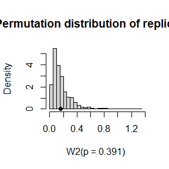

## 第三题

*问题描述：*6.4节中，方差相等的count 5 test是基于极端点的最大数量的。例6.15展示了count 5准则并不适用于样本量不相等的情况。在样本量不相等的情况下，基于极端点的最大数量，使用permutation test来检验方差是否相等。

*思路：*首先根据极端点数量大于5则方差不等的思想，编写函数使其具有count 5 test的功能。然后生成样本量不等、方差相等的两组数据。在R次permutation中，打乱样本顺序，实施count 5 test，计算统计量，判断是否拒绝原假设。

*解：* 编写函数`count 5 test`，统计量为`max(c(extrem_x, extrem_y))`，如果统计量大于5，则返回值为1，拒绝$H_0$，否则，返回值为0，没有充足理由拒绝$H_0$。

```r
count5test = function(x, y){
  x = x - mean(x)
  y = y - mean(y)
  # count
  extrem_x = sum(x > max(y)) + sum(x < min(y))
  extrem_y = sum(y > max(x)) + sum(y < min(x))
  return(max(c(extrem_x, extrem_y)))
}
```

为了更全面地展示结果，我们分别考虑样本方差相等和不相等的两种情况，并在每种情况下逐渐增大y的样本量。

（1）样本方差相等：两组正态分布样本，初始样本量分别为20、20，方差相等，均为1。replicates的次数为999。y的样本量从20增加至100，步长为10：

```r
R = 999
n1 = 20
mu1 = mu2 = 0
sigma1 = sigma2 = 1
y_seq = seq(20,100,10)
p1 = numeric(length(y_seq))

for (j in 1:length(y_seq)) {
  set.seed(6)
  n2 = y_seq[j]
  K = 1:(n1+n2)
  x = rnorm(n1, mu1, sigma1)
  y = rnorm(n2, mu2, sigma2)
  C0 = count5test(x, y)

  C_rep = numeric(R)
  for (i in 1:R) {
    k = sample(K, size = n1, replace = FALSE)
    z = c(x, y)
    x1 = z[k]
    y1 = z[-k]
    C_rep[i] = count5test(x1, y1)
  }
  p1[j] = mean(c(C0, C_rep) >= C0)
}
p1
```

```
## [1] 0.887 0.871 0.503 0.584 0.638 0.379 0.363 0.477 0.479
```

（2） 样本方差不相等： 两组正态分布样本，初始样本量分别为20、20，方差分别为1和1.5。replicates的次数为999。y的样本量从20增加至100，步长为10：

```r
R = 999
n1 = 20
mu1 = mu2 = 0
sigma1 = 1
sigma2 = 1.5
y_seq = seq(20,100,10)
p2 = numeric(length(y_seq))

for (j in 1:length(y_seq)) {
  set.seed(6)
  n2 = y_seq[j]
  K = 1:(n1+n2)
  x = rnorm(n1, mu1, sigma1)
  y = rnorm(n2, mu2, sigma2)
  C0 = count5test(x, y)

  C_rep = numeric(R)
  for (i in 1:R) {
    k = sample(K, size = n1, replace = FALSE)
    z = c(x, y)
    x1 = z[k]
    y1 = z[-k]
    C_rep[i] = count5test(x1, y1)
  }
  p2[j] = mean(c(C0, C_rep) >= C0)
}
p2
```

```
## [1] 0.005 0.006 0.004 0.008 0.034 0.013 0.015 0.045 0.039
```

最后，我们将结果输出成表格：

```r
value = rbind(p1, p2)
colnames(value) = y_seq
rownames(value) = c('方差相等', '方差不相等')
knitr::kable(round(value, 3), format = "latex", align='c')
```

[output not shown]

而在备择假设成立，即样本方差不相等的设定下，随着样本量不相等的程度增加，P值逐渐变大。虽然在0.05的显著性水平下，始终可以拒绝原假设，但是P值变大说明拒绝原假设的能力越来越弱，样本落在拒绝域内的可能性越来越小，犯二类错误的可能性变大。

综上所述，当样本量不相等时，count 5 test犯一类、二类错误的可能性均增加。这就是该检验的缺点。

# HW7

## 第一题

*问题描述：*考虑如下的模型：
$$P(Y=1|X_1,X_2,X_3)=\dfrac{\exp(a+b_1X_1+b_2X_2+b_3X_3)}{1+\exp(a+b_1X_1+b_2X_2+b_3X_3)},$$
其中$X_1\sim P(1)$，$X_2\sim Exp(1)$，$X_3\sim B(1,0.5)$。

- 设计一个函数，以$N,~b_1,~b_2,~b_3,~f_0$作为输入的参数，并输出$a$;
- 给定具体的输入值$N=10^6,~b_1=0,~b_2=1,~b_3=-1,~f_0=0.1,~0.01,~0.001,~0.0001$;
- 画出$-\log f_0~\mbox{vs}~a$的图像。

*思路：*根据模型表达式，写一个用`uniroot`方法来求解$a$的函数。然后将题目给定的参数值输入到函数中，求解$a$，并绘制图像。

*解：*在设计的函数`alpha.solve`中，我们首先分别生成随机数$X_1$，$X_2$，$X_3$各$N$个。然后，`alpha.solve`调用另一个自己设计的函数`g.alpha`，`g.alpha`的功能是构建关于$\alpha$的函数$g(\alpha)$：
$$g(\alpha) =
\dfrac{1}{N}\sum_{i=1}^N\dfrac{1}{1+\exp(-\alpha-b_1x_1-b_2x_2-b_3x_3)}-f_0.$$
最后用**R**自带的`uniroot`方法求解方程$g(\alpha)=0$的根，输出方程的解$a$，代码如下：

```r
alpha.solve = function(alpha, N, b1, b2, b3, f0){
  x1 = rpois(N, 1)
  x2 = rexp(N, 1)
  x3 = rbinom(N, 1, 0.5)
  g.alpha = function(alpha){
  temp = exp(-alpha-b1*x1-b2*x2-b3*x3)
  mean(1/(1+temp)) - f0
  }
  solution = uniroot(g.alpha, c(-20, 20))
  alpha = round(solution$root, 5)
  return(alpha)
}

set.seed(7)
f = c(0.1, 0.01, 0.001, 0.0001)
alpha.root = numeric(length(f))
for (i in 1:length(f)) {
  alpha.root[i] = alpha.solve(N=1e6, b1=0, b2=1, b3=-1, f0=f[i])
}
alpha.root
```

```
## [1]  -3.16924  -6.07592  -8.72079 -11.30658
```

可以看出，函数成功地输出了$a$。接下来通过图像观察$-\log f_0$和$a$之间的关系，二者之间为线性关系，随着$f_0$增加，$-\log f_0$降低，$a$增大。

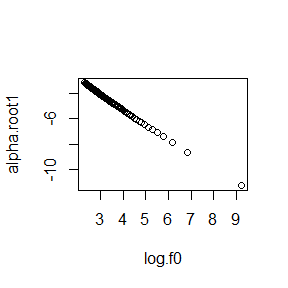

## 第二题

*问题描述：*使用随机游走Metropolis sampler来生成标准拉普拉斯分布。增量从正态分布中生成。当提议分布的方差不同时，比较这些生成的链。此外，请比较每条链的接受率。

*思路：*目标分布是标准拉普拉斯分布。由于增量从正态分布中生成，因此提议分布是正态分布，均值为上一步生成的随机数，方差待定。分别在提议分布的方差为0.05，0.5，2，16的条件下生成链。

*解：*注意到当提议分布是正态分布$N(X_t,\sigma^2)$时，$g(r|s) = g(s|r)$，因此候选点$Y$的接受概率为：
$$\alpha(X_t,Y) =
\min(1,\dfrac{f(Y)}{f(X_t)}).$$
此外，标准拉普拉斯分布的密度函数是$f(x)=\frac{1}{2}e^{-|x|},~x\in R$。

生成链的算法流程如下：

（1）指定$X_1$为30（也可以从提议分布中生成，但这里为了比较四种方差，就固定为30）；

（2）第$i(i = 1,...,N)$次循环中：

1. 从提议分布$N(X_{i-1},\sigma^2)$中生成$Y$；
2. 从$U(0,1)$中生成$U$；
3. 计算$\alpha = f(Y)/f(X_{i-1})$，如果$U\leq \alpha$，则接受$Y$，并令$X_{i}=Y$；否则令$X_{i}=X_{i-1}$。

```r
# Metropolis函数，返回生成的样本x和接受率rate
laplace = function(x){exp(-abs(x))/2}
Metropolis = function(N, x0, sigma) {
  x = numeric(N)
  u = runif(N)
  x[1] = x0
  rate = 0
  for (i in 2:N) {
    y = rnorm(1, x[i-1], sigma)
    if(u[i] <= laplace(y) / laplace(x[i-1])){
      x[i] = y
      rate = rate + 1
    }
    else{
      x[i] = x[i-1]
    }
  }
  return(list(x = x, rate = rate/N))
}
```

我们在提议分布的方差为0.05，0.5，2，16的条件下生成链，每条链的样本为5000个。

```r
set.seed(7)
N = 5000
sigma = c(0.05, 0.5, 2,  16)
x0 = 30
rw1 = Metropolis(N, x0, sigma[1])
rw2 = Metropolis(N, x0, sigma[2])
rw3 = Metropolis(N, x0, sigma[3])
rw4 = Metropolis(N, x0, sigma[4])

# 输出接受率
accepted = data.frame(sigma = sigma,
                      accepted.rate = c(rw1$rate, rw2$rate, rw3$rate, rw4$rate))
knitr::kable(accepted,format='latex')
```

[output not shown]

最后，通过图像来比较这些生成的链。

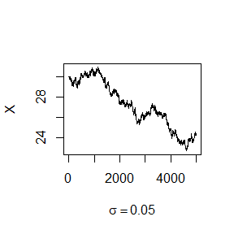

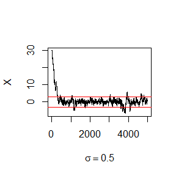

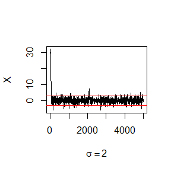

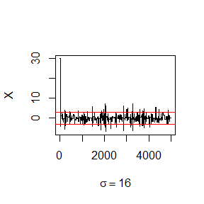

在第一个图中（$\sigma$ = 0.05），接受率很大，但在5000 次迭代中没有收敛到目标分布。在第二个图中（$\sigma$ = 0.5），链收敛得非常缓慢。在第三个图中（$\sigma$ = 2），链混合的效果比较好，约100步就收敛到目标分布。在第四个图中（$\sigma$ = 16），接受率非常小，因此第四条链收敛的效率很低。

## 第三题

*问题描述：*使用Gibbs sampler来生成二元正态链$S_t = (X_t,Y_t)$，随机变量具有0均值，单位标准差和0.9的相关性。丢弃适当的预烧样本后，绘制出生成的样本的图像。在生成的样本上拟合一个简单的线性回归模型$Y=\beta_0+\beta_1X$，检查模型的残差的正态性、方差是否为常数。

*思路：*Gibbs sampler的思想是从$f(X_j|x_{(-j)})$中生成样本$X_j$，在本题二维正态的条件下，计算条件分布的参数，然后生成样本即可。

*解：*根据联合正态分布的条件分布的性质，有：
$$f(x|y)\sim
N(\mu_1+\dfrac{\rho\sigma_1}{\sigma_2}(y-\mu_2),(1-\rho^2)\sigma_1^2),$$
$$f(y|x)\sim
N(\mu_2+\dfrac{\rho\sigma_2}{\sigma_1}(x-\mu_1),(1-\rho^2)\sigma_2^2).$$
按照如下流程生成$T$个样本。在第$t$次生成中：

（1）令$(x,y)=S(t-1)$;

（2）从$f(X|y)$中生成$X(t)$；

（3）更新$x_1$为$X(t)$；

（4）从$f(Y|x)$中生成$Y(t)$；

（5）令$S(t)=(X(t),Y(t))$。

将$\mu_1 = \mu_2=0,~\sigma_1=\sigma_2=1,~\rho = 0.9$代入，生成5000个样本。丢弃1000个预烧样本后，绘制出生成的样本的图像。

```r
# 定义参数
N = 5000
burn = 1000
S = matrix(0, N, 2)
rho = 0.9
mu1 = mu2 = 0
sigma1 = sigma2 = 1
k1 = sqrt(1-rho^2)*sigma1
k2 = sqrt(1-rho^2)*sigma2
# 初始化
S[1, ] = c(mu1, mu2)
for (i in 2:N) {
  y = S[i-1, 2]
  m1 = mu1 + rho * (y - mu2) * sigma1/sigma2
  S[i, 1] = rnorm(1, m1, k1)
  x = S[i, 1]
  m2 = mu2 + rho * (x - mu1) * sigma2/sigma1
  S[i, 2] = rnorm(1, m2, k2)
}
s = S[(burn + 1):N, ]
```

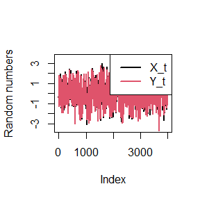

图像中，黑色代表样本$X_t$，红色代表样本$Y_t$。丢弃1000个预烧样本后，生成的链达到收敛状态。从两条链的重合度可以看出，二者相关系数很高，并且均值约为0.

线性回归模型残差性质的检验通过`lm`函数来实现。从残差散点图可以看出，残差的取值在0附近波动，没有呈现出异方差的特点，可以认为方差是常数。利用QQ图，可以认为残差满足正态性假定。

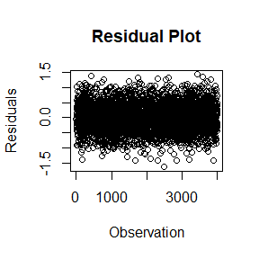

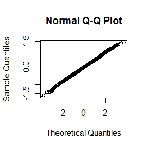

## 第四题

*问题描述：*根据例9.1，使用Gelman-Rubin方法来监测链的收敛性，并且继续生成链，直到在$\hat R<1.2$的准则下近似收敛到目标分布。同样地，使用coda包，通过Gelman-Rubin方法监测链的收敛性。

*思路：*Gelman-Rubin方法通过比较多个独立运行的MCMC链的方差来检查链是否已经收敛到了目标分布。指定参数值和链的条数，计算Gelman-Rubin统计量，并和1.2的阈值进行比较，判断是否收敛。

*解：*使用Metropolis-Hastings方法从Rayleigh分布中生成样本。Rayleigh分布的密度函数为：
$$f(x)=\dfrac
x{\sigma^2}e^{-x^2/(2\sigma^2)},\quad x\geq 0, \sigma>0.$$
生成的流程及函数如下：

（1）指定提议分布$g(\cdot|X)$ 为$\chi^2(X)$；

（2）从$\chi^2(1)$中生成$X_1$；

（3）重复$i=2,\ldots,N$：

1. 从$\chi^2(X_{i-1})$中生成$Y$；
2. 从$U(0,1)$中生成$U$；
3. 计算$\alpha(X_{i-1},Y)=\frac{f(Y)g(X_{i-1}|Y)}{f(X_{i-1})g(Y|X_{i-1})}$。若$U\leq \alpha(X_{i-1},Y)$则 接受$Y$并令$X_i=Y$，否则令$X_{i}=X_{i-1}$。

```r
# Rayleigh function returns pdf
Rayleigh = function(x, sigma) {
  if (any(x < 0)) return (0)
  stopifnot(sigma > 0)
  return((x / sigma^2) * exp(-x^2 / (2*sigma^2)))
}
# Rchain function generates chain for Rayleigh dist
Rchain = function(sigma, N, X1) {
  x = rep(0, N)
  x[1] = X1
  u = runif(N)
  for (i in 2:N) {
    xt = x[i-1]
    y = rchisq(1, df = xt)
    r1 = Rayleigh(y, sigma) * dchisq(xt, df = y)
    r2 = Rayleigh(xt, sigma) * dchisq(y, df = xt)
    if (u[i] <= r1/r2){
      x[i] = y
    }else{
      x[i] = xt
    }
  }
  return(x)
}
```

在Gelman-Rubin方法中，scalar summary statistic $\psi_{ij}$ 是时刻$i$下第$j$条链的均值。Gelman-Rubin统计量$\hat R$的计算公式如下：
$$\hat R = \dfrac{\hat Var(\psi)}{W},$$
其中，$\hat Var(\psi) = \dfrac{n-1}{n}W+\dfrac{1}{n}B$，$W$为$\psi_{ij}$的组内方差，$B$为$\psi_{ij}$的组间方差。实现Gelman-Rubin方法的函数如下：

```r
# 函数Gelman.Rubin以psi作为输入
Gelman.Rubin = function(psi) {
  psi = as.matrix(psi)
  n = ncol(psi)
  k = nrow(psi)
  B = n * var(rowMeans(psi))
  W = mean(apply(psi, 1, "var"))
  v.hat = W*(n-1)/n + B/n
  r.hat = v.hat / W
  return(r.hat)
}
```

与例9.1一致，我们在$\sigma^2=16$的条件下，生成4条链，每一条链指定不同的初始值。生成20000个样本并将前1000个作为预烧样本丢弃。

```r
# 参数
set.seed(7)
sigma = 4
burn = 1000
chain.len = 20000
chain.num = 4
# x0 = rchisq(4, df=1)
x0 = c(2, 6, 10, 14)   # initial values
# 生成四条不同初始值的链
MCMC.chain = matrix(0, nrow = chain.num, ncol = chain.len)
for (i in 1:chain.num){
  MCMC.chain[i, ] = Rchain(sigma, chain.len, x0[i])
}

psi0 = t(apply(MCMC.chain, 1, cumsum))
psi = psi0
for (i in 1:nrow(psi0)){
  psi[i,] = psi0[i,] / (1:ncol(psi0))
}
```

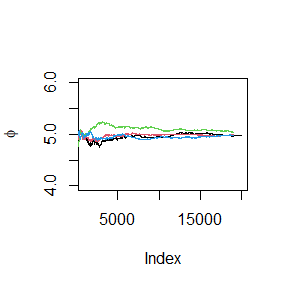

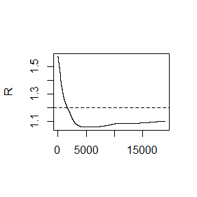

4条链在$\hat R<1.2$的准则下均收敛到目标分布。需要说明的是，Metropolis-Hastings方法使用卡方分布生成初始值，但由于该方法有随机性，可能生成较为接近的初始值，因此本题的解答中，人为给定了四个差别较大的初始值，以凸显链的生成过程的差别。

接下来，使用coda包实现上述过程。以`obj`作为mcmc变量，输入到函数`gelman.plot`中，图片展示的是 Gelman-Rubin 收缩因子随着迭代次数的增加而演变的规律。由图像可知，MCMC链的收敛效果较好，这一结论与第一问的结论一致。

```r
obj = mcmc.list(mcmc(MCMC.chain[1, ]), mcmc(MCMC.chain[2, ]),
                 mcmc(MCMC.chain[3, ]), mcmc(MCMC.chain[4, ]))
gelman.diag(obj)
```

```
## Potential scale reduction factors:
##
##      Point est. Upper C.I.
## [1,]          1          1
```

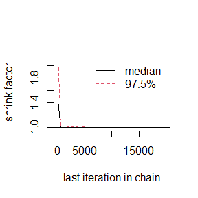

```r
gelman.plot(obj)
```

# HW8

## 第一题

*问题描述：*设$X_1,...,X_n\sim^{iid}~Exp(\lambda)$。由于某种原因，只知道$X_i$落在某个区间$(u_i,v_i)$，其中$u_i<v_i$是两个非随机的已知常数。这种数据成为区间删失数据。

（1）试分别直接极大化观测数据的似然函数与采用EM算法求解$\lambda$的MLE。证明EM算法收敛于观测数据的MLE，且收敛有线性速度。

（2）设$(u_i,v_i),~i=1,...n(=10)$的观测值为$(11,12),~(8,9),...$（略）。试分别编程实现上述两种算法以得到$\lambda$的MLE的数值解。

*思路：*根据区间删失数据的似然函数，首先极大化似然函数，求解MLE；然后再写出完全数据的似然函数，用EM算法求解$\lambda$。将MLE与EM算法求出的两式进行对比，找到二者之间的关系并利用它证明线性收敛。

*解：*（1）由于$Exp(\lambda)$的分布函数为$F(x) = 1-e^{-\lambda x}$，因此区间删失数据的对数似然函数为：
$$l_o(\lambda) =
\ln[\prod_{i=1}^nP_{\lambda}(u_i\leq X_i\leq v_i)]$$
$$= \sum_{i=1}^n\ln(e^{-\lambda u_i}-e^{-\lambda
v_i}).$$
令上式对$\lambda$的偏导为0，即$\frac{\partial l_o(\lambda)}{\partial \lambda}=0$，解得：
$$\sum_{i=1}^n\dfrac{-u_ie^{-\lambda
(u_i-v_i)}+v_i}{e^{-\lambda (u_i-v_i)}-1}=0.$$
$\lambda$的MLE为上式的数值解（无法求出解析解）。

EM算法中，我们首先给出完全数据的似然函数：
$$l_c(\lambda) =
\ln[\prod_{i=1}^nf_{\lambda}(X_i)]$$
$$= n\ln\lambda -\sum_{i=1}^n\lambda X_i.$$
E-Step：第$j+1$步的时候，以观测到的数据$u_i,v_i$和第$j$步求出的$\hat\lambda^{(j)}$作为条件，计算完全数据的似然函数的期望。
$$Q(\lambda|\hat\lambda^{(j)})=E_{X|u_i, v_i,
\hat\lambda^{(j)}}[l_c(\lambda)]$$
$$=n\ln\lambda-\lambda\sum_{i=1}^n E[x_i|u_i, v_i,
\hat\lambda^{(j)}]$$
其中，$E[x_i|u_i, v_i, \hat\lambda^{(j)}]$的求解如下（事实上，在线性收敛性的证明过程中我们发现，积分式还可以进一步化简）：
$$E[x_i|u_i, v_i, \hat\lambda^{(j)}] =
\int_{u_i}^{v_i}\dfrac{x\hat\lambda^{(j)}e^{-\hat\lambda^{(j)}x}}{e^{-\hat\lambda^{(j)}u_i}-e^{-\hat\lambda^{(j)}v_i}}dx.$$

M-Step：对$Q(\lambda|\hat\lambda^{(j)})$求导，并令导数为0：
$$\dfrac{\partial
Q(\lambda|\hat\lambda^{(j)})}{\partial \lambda} = \dfrac{n}{\lambda} -
\sum_{i=1}^nE[x_i|u_i, v_i, \hat\lambda^{(j)}].$$

$\hat\lambda^{(j+1)}$即导数为0时的解：
$$\hat\lambda^{(j+1)} =
\dfrac{n}{\sum_{i=1}^nE[x_i|u_i, v_i, \hat\lambda^{(j)}]}.$$

下面证明EM算法收敛于观测数据的MLE，且收敛有线性速度：

将EM算法的迭代式进行化简，有$\hat\lambda^{(j+1)} = f(\hat\lambda^{(j)})$的关系式，且该式与MLE方法中$\hat\lambda_{MLE}$的表达式有关：
$$\hat\lambda^{(j+1)} =
\dfrac{n}{\sum_{i=1}^n\int_{u_i}^{v_i}\dfrac{x\hat\lambda^{(j)}e^{-\hat\lambda^{(j)}x}}{e^{-\hat\lambda^{(j)}u_i}-e^{-\hat\lambda^{(j)}v_i}}dx}$$
$$= \dfrac{1}{\dfrac{1}{n}\sum_{i=1}^n
\dfrac{u_ie^{-\hat\lambda^{(j)}u_i}-v_ie^{-\hat\lambda^{(j)}v_i}}{e^{-\hat\lambda^{(j)}u_i}-e^{-\hat\lambda^{(j)}v_i}}+\dfrac{1}{\hat\lambda^{(j)}}}\triangleq
f(\hat\lambda^{(j)}).$$

由于$\hat\lambda_{MLE}$使得分母中的$\sum_{i=1}^n \dfrac{u_ie^{-\hat\lambda^{(j)}u_i}-v_ie^{-\hat\lambda^{(j)}v_i}}{e^{-\hat\lambda^{(j)}u_i}-e^{-\hat\lambda^{(j)}v_i}}$为0，因此有：$\hat\lambda_{MLE}=f(\hat\lambda_{MLE}).$

接下来，对$f(\lambda)$求导，为简化记号，记$m(\lambda)=\sum_{i=1}^n \dfrac{u_ie^{-\lambda u_i}-v_ie^{-\lambda v_i}}{e^{-\lambda u_i}-e^{-\lambda v_i}}$：
$$f'(\lambda) =
-\dfrac{1}{(\dfrac{1}{n}m(\lambda)+\dfrac{1}{\lambda})^2}(\dfrac{1}{n}m'(\lambda)-\dfrac{1}{\lambda^2}).$$
将$\hat\lambda_{MLE}$代入并化简：
$$f'(\hat\lambda_{MLE}) =
1-\dfrac{\lambda^2}{n}m'(\hat\lambda_{MLE}),$$
$$= 1-\dfrac{1}{n}\sum_{i=1}^n
\dfrac{\lambda^2(u_i-v_i)^2}{e^{\lambda(u_i-v_i)}+e^{-\lambda(u_i-v_i)}-2}$$
利用$e^x=1+x+\dfrac{x^2}{2}+o(x^2)$，$e^{-x}=1-x+\dfrac{x^2}{2}+o(x^2)$，对上式第二项的分母进行Taylor展开：
$$e^{\lambda(u_i-v_i)}+e^{-\lambda(u_i-v_i)}-2=(1+\lambda(u_i-v_i)+\dfrac{\lambda^2(u_i-v_i)^2}{2}+o(\lambda^2(u_i-v_i)^2)$$
$$+
(1-\lambda(u_i-v_i)+\dfrac{\lambda^2(u_i-v_i)^2}{2}+o(\lambda^2(u_i-v_i)^2)-2$$
$$= \lambda^2(u_i-v_i)^2 +
o(\lambda^2(u_i-v_i)^2).$$
因此有$0<f'(\hat\lambda_{MLE})<1$。

又由于$f''(\hat\lambda_{MLE})$存在连续，因此$\forall~0<k<1,~\exists~\sigma>0$，使得$\lambda\in(\hat\lambda_{MLE}-\sigma,\hat\lambda_{MLE}+\sigma)$内有$|f'(\lambda)|<k$，进而对$a,b\in(\hat\lambda_{MLE}-\sigma,\hat\lambda_{MLE}+\sigma)$，有：
$$|f(a)-f(b)|=|f'(c)||a-b|<
k|a-b|,~c\in(a,b),$$
由不动点引理，在$(\hat\lambda_{MLE}-\sigma,\hat\lambda_{MLE}+\sigma)$内存在$f(\lambda)$唯一的不动点，而之前已解得$\hat\lambda_{MLE}=f(\hat\lambda_{MLE})$， 即$\hat\lambda_{MLE}$是$f(\cdot)$的不动点。

再由$0<f'(\hat\lambda_{MLE})<1$的结论知，EM算法以线性速度收敛于MLE。

（2）给定$(u_i,v_i),~i=1,...n(=10)$的观测值的情况下。我们首先极大化似然函数得到$\lambda$的MLE的数值解。

```r
ui = c(11, 8, 27, 13, 16, 0, 23, 10, 24, 2)
vi = c(12, 9, 28, 14, 17, 1, 24, 11, 25, 3)
partial.l = function(lambda){
  equation = (-ui*exp(-lambda*(ui-vi))+vi) / (exp(-lambda*(ui-vi))-1)
  return(sum(equation))
}
cat("Lambda estimated by MLE:", uniroot(partial.l, lower = 0.01, upper = 3)$root)
```

```
## Lambda estimated by MLE: 0.07194754
```

然后根据EM算法求解$\lambda$。

```r
# E-Step 的条件期望的被积函数
integrand = function(x, lambda, uk, vk) {
  numerator = x * lambda * exp(-lambda * x)
  denominator = exp(-lambda * uk) - exp(-lambda * vk)
  return(numerator / denominator)
}

# EM算法
em_algorithm = function(lambda_initial, num_iterations, eps, u, v) {
  n = length(u)
  lambda = lambda_initial
  pre_lambda = lambda_initial
  # 迭代
  for (iteration in 1:num_iterations) {
    E = numeric(n)
    for (k in 1:n) {
      E[k] = integrate(integrand, lower = u[k], upper = v[k],
                       lambda = lambda, uk = u[k], vk = v[k])$value
    }
    lambda = n/sum(E)
    # whether to stop
    if (abs(lambda - pre_lambda) < eps) {
      break
    }
    pre_lambda = lambda
  }
  return(lambda)
}

lambda_initial = 0.01
num_iterations = 1e4
eps = 1e-5
em_lambda = em_algorithm(lambda_initial, num_iterations, eps, u = ui, v = vi)
cat("Lambda estimated by EM algorithm:", em_lambda)
```

```
## Lambda estimated by EM algorithm: 0.0719735
```

通过数值求解的结果可知，MLE与EM算法有着非常相近的求解结果，这一现象支持第一小题的结论，即EM算法收敛于观测数据的MLE。

## 第二题

*问题描述：*在Morra game中，如果从payoff matrix（收益矩阵）的每一个元素中减去一个常数，或者将收益矩阵的每个元素乘一个正常数，则最优策略集不会改变。然而，单纯形法可能终止于不同的基本可行点（也是最优的）。计算`B <- A + 2`，找到game B的解，验证其为原game A的极值点(11.12)-(11.15)之一，并求出game A和game B的值。

*思路：*在Morra game中，第一个玩家的目标是要最大化他的收益，相应的最优策略为$x^*$；第二个玩家的目标是要最小化他的损失，相应的最优策略为$y^*$。game的期望payoff是$v = x^{*^T}Ay^*$，用simplex method进行最优化问题（最大化$v$、最小化$v$）的求解。

*解：*我们调用`simplex()`函数分别求解最大化$v$、最小化$v的最优化问题，参数`maxi`分别设置为`TRUE`和`FALSE`。将这一步骤封装在自己编写的函数`solve.game`中。

```r
library(boot)
solve.game = function(payoff.matrix){
  # preprocess
  min.A = min(A); A = A - min.A; max.A = max(A); A = A / max(A)
  m = nrow(A)
  n = ncol(A)
  iter = n^3

  # max v
  # objective function
  a = c(rep(0, m), 1)
  # constraint 1 >=，但simplex函数中的A1是<=，所以这里A1前有负号
  A1 = -cbind(t(A), rep(-1, n))
  b1 = rep(0, n)
  # constraint 2 sum(x)=1
  A3 = t(as.matrix(c(rep(1, m), 0)))
  b3 = 1
  sx = simplex(a=a, A1=A1, b1=b1, A3=A3, b3=b3, maxi=TRUE, n.iter=iter)

  # min v
  # objective function
  a = c(rep(0, n), 1)
  # constraint 1 <=
  A1 = cbind(A, rep(-1, m))
  b1 = rep(0, m)
  # constraint 2 sum(y)=1
  A3 = t(as.matrix(c(rep(1, n), 0)))
  b3 = 1
  sy = simplex(a=a, A1=A1, b1=b1, A3=A3, b3=b3,
maxi=FALSE, n.iter=iter)
  solution.list = list("A" = A * max.A + min.A,
                "x" = sx$soln[1:m],
                "y" = sy$soln[1:n],
                "v" = sx$soln[m+1] * max.A + min.A)
  solution.list
}
```

```r
# payoff matrix
A <- matrix(c( 0,-2,-2,3,0,0,4,0,0,
2,0,0,0,-3,-3,4,0,0,
2,0,0,3,0,0,0,-4,-4,
-3,0,-3,0,4,0,0,5,0,
0,3,0,-4,0,-4,0,5,0,
0,3,0,0,4,0,-5,0,-5,
-4,-4,0,0,0,5,0,0,6,
0,0,4,-5,-5,0,0,0,6,
0,0,4,0,0,5,-6,-6,0), 9, 9)
B <- A + 2
# 计算A的解和B的解
round(cbind(solve.game(A)$x, solve.game(A)$y),7)
```

```
##         [,1]      [,2]
## x1 0.0000000 0.0000000
## x2 0.0000000 0.0000000
## x3 0.4098361 0.4098361
## x4 0.0000000 0.0000000
## x5 0.3278689 0.3278689
## x6 0.0000000 0.0000000
## x7 0.2622951 0.2622951
## x8 0.0000000 0.0000000
## x9 0.0000000 0.0000000
```

```r
round(cbind(solve.game(B)$x, solve.game(B)$y),7)
```

```
##         [,1]      [,2]
## x1 0.0000000 0.0000000
## x2 0.0000000 0.0000000
## x3 0.4098361 0.4098361
## x4 0.0000000 0.0000000
## x5 0.3278689 0.3278689
## x6 0.0000000 0.0000000
## x7 0.2622951 0.2622951
## x8 0.0000000 0.0000000
## x9 0.0000000 0.0000000
```

```r
# 验证game B的解是否为game A的极值点之一
epointA = round(c(0, 0, 25/61, 0, 20/61, 0, 16/61, 0, 0), 7)
epointA == round(solve.game(B)$x, 7)
```

```
##   x1   x2   x3   x4   x5   x6   x7   x8   x9
## TRUE TRUE TRUE TRUE TRUE TRUE TRUE TRUE TRUE
```

```r
epointA == round(solve.game(B)$y, 7)
```

```
##   x1   x2   x3   x4   x5   x6   x7   x8   x9
## TRUE TRUE TRUE TRUE TRUE TRUE TRUE TRUE TRUE
```

```r
solve.game(A)$v
```

```
## x10
##   0
```

```r
solve.game(B)$v
```

```
## x10
##   0
```

# HW9

## 第一题

*问题描述：*为什么要用`unlist()`将list转化为atomic vector？为什么`as.vector()`不适用？

*解答：*原因如下：

- `unlist()`可以将具有多种数据类型的list转换为一个数据类型一致的向量（按照上课说的就高原则，例如int和chr类型的元素全部转化为chr类型）。
- `as.vector()`主要用于改变向量的类别，它无法将列表转换为扁平化的结构。尤其是在列表为嵌套结构的时候，对数据分析的影响很大。事实上，list是否为嵌套形式，`as.vector(list)`的结果还是list。

因此，在将list转换为原子向量时，`unlist()`函数更适用。

举个例子：

```r
list1 = list('a', 2, 5, 'd')
unlist(list1)
```

```
## [1] "a" "2" "5" "d"
```

```r
as.vector(list1)
```

```
## [[1]]
## [1] "a"
##
## [[2]]
## [1] 2
##
## [[3]]
## [1] 5
##
## [[4]]
## [1] "d"
```

## 第二题

*问题描述：*`dim()`应用于vector的时候返回什么？

*解答：*返回NULL，这是因为vector是一维的，与矩阵或数组不同，它没有维度信息。正确用法是使用`length()`。

举个例子：

```r
v = list(1, 2, 5, 7)
dim(v)
```

[output not shown]

```r
length(v)
```

```
## [1] 4
```

## 第三题

*问题描述：*如果`is.matrix(x)`为`TRUE`，那么`is.array(x)`返回什么？

*解答：* `is.array(x)`也返回`TRUE`。因为matrix是array的一种特殊形式（矩阵是二维情况下的数组）。

举个例子：

```r
m = matrix(c(1, 2, 5, 7), 2, 2)
is.matrix(m)
```

```
## [1] TRUE
```

```r
is.array(m)
```

```
## [1] TRUE
```

## 第四题

*问题描述：*`as.matrix()`应用于一个列类型不同的data frame会发生什么？

*解答：*data frame会被转换为一个矩阵，并且所有列会被转换为相同的数据类型。转换的原则为：

logical < integer < double < character < list

举个例子：

```r
df <- data.frame(
  col1 = c("a", "b", "c"),
  col2 = c(1, 2, 8),
  col3 = c(TRUE, TRUE, FALSE),
  stringsAsFactors = FALSE
)
cat('type of column 1:', typeof(df$col1), '\n')
```

```
## type of column 1: character
```

```r
cat('type of column 2:', typeof(df$col2), '\n')
```

```
## type of column 2: double
```

```r
cat('type of column 3:', typeof(df$col3), '\n')
```

```
## type of column 3: logical
```

```r
typeof(as.matrix(df))
```

```
## [1] "character"
```

## 第五题

*问题描述：*会有0行的data frame吗？0列呢？

*解答：*有0行0列的data frame，但事实上，列是data frame的基本组成部分，0列的data frame没有任何意义。

举个例子：

```r
df = data.frame()
ncol(df)
```

```
## [1] 0
```

```r
nrow(df)
```

```
## [1] 0
```

## 第六题

*问题描述：*下面的函数是对vector进行标准化，使之在[0, 1]之间，你将会怎么把它应用到data frame的每一列？又怎么把它应用到data frame的每一个数值型列？

```r
scale01 <- function(x) {
  rng <- range(x, na.rm = TRUE)
  (x - rng[1]) / (rng[2] - rng[1])
}
```

```r
df1 = data.frame(
  col1 = c(1, 2, NA, 4),
  col2 = c(5, NA, 7, 8),
  col3 = c(NA, 10, 11, 12)
)

lapply(df1, scale01)
```

```
## $col1
## [1] 0.0000000 0.3333333        NA 1.0000000
##
## $col2
## [1] 0.0000000        NA 0.6666667 1.0000000
##
## $col3
## [1]  NA 0.0 0.5 1.0
```

接下来，我们生成一个混合型的data frame。为了对每一个数值型列进行标准化，我们首先要识别出列的类型。从结果可以看出，`vapply`函数正确识别出了数值型列是第一列和第三列，并计算出了元素的标准化值。

```r
df2 = data.frame(
  col1 = seq(1,4,1),
  col2 = rep(TRUE, 4),
  col3 = seq(9,15,2),
  col4 = rep('a', 4),
  stringsAsFactors = FALSE
)
numeric.idx = vapply(df2, is.numeric, FUN.VALUE=logical(1))
lapply(df2[, numeric.idx], scale01)
```

```
## $col1
## [1] 0.0000000 0.3333333 0.6666667 1.0000000
##
## $col3
## [1] 0.0000000 0.3333333 0.6666667 1.0000000
```

## 第七题

*问题描述：*用`vapply()`完成以下操作：

1. 计算一个数值型data frame的每一列的标准差standard deviation.
2. 计算一个混合型data frame的每一个数值型列的标准差standard deviation.(Hint: use `vapply()` twice.)

*解答：* a) 构建一个数值型data frame，并用`vapply()`计算每一列的标准差standard deviation，注意需要指定默认值`FUN.VALUE`。

```r
df1 = data.frame(
  col1 = seq(1,4,1),
  col2 = seq(5,8,1),
  col3 = seq(9,15,2)
)
vapply(df1, sd, FUN.VALUE=0)
```

```
##     col1     col2     col3
## 1.290994 1.290994 2.581989
```

2. 构建一个混合型data frame，先用`vapply()`识别每一列的类型，如果是数值型列，则记录列的下标，然后再用一次`vapply()`计算数值型列的标准差standard deviation，同样地，需要指定默认值`FUN.VALUE`。

```r
df2 = data.frame(
  col1 = seq(1,4,1),
  col2 = rep(TRUE, 4),
  col3 = seq(9,15,2),
  col4 = rep('a', 4),
  stringsAsFactors = FALSE
)
numeric.idx = vapply(df2, is.numeric, FUN.VALUE=logical(1))
vapply(df2[, numeric.idx], sd, FUN.VALUE=0)
```

```
##     col1     col3
## 1.290994 2.581989
```

## 第八题

*问题描述：*考虑一个二元密度函数：
$$f(x,y) \propto
C_n^xy^{x+a+1}(1-y)^{n-x+b-1},~x=0,1,...,n,~0\leq y\leq 1.$$
对于固定的$a,b,n$，边际分布分别为$B(n,y)$和$Beta(x+a,n-x+b)$。用Gibbs sampler生成一条具有目标联合密度的链。

- 写一个R函数；
- 写一个Rcpp函数；
- 用函数`microbenchmark`来比较两个函数的运行时间。

*解答：*Gibbs算法的流程如下所示，在每一轮迭代中：

1）设$(x,y)=(X_{t-1},Y_{t-1})$，

2）从$f(X|y)$生成样本$X^*_t$，

3）令$x_t = X^*_t$，

4）从$f(Y|x)$生成样本$Y^*_t$，

5）设$(X_{t},Y_{t})=(X^*_t,Y^*_t)$。

根据题设条件，$f(X|y)$和$f(Y|x)$分别为$B(n,y)$和$Beta(x+a,n-x+b)$。将上述流程分别写成R函数和Rcpp函数。

```r
gibbsR = function(N, burn, a, b, n, seed){
  # N: length of chain
  # burn: burn-in length
  # a, b, n: parameter of density
  # seed: random seed
  set.seed(seed)
  data = matrix(0, N, 2)
  data[1, ] = c(n-1, 1/2)
  for (i in 2:N) {
    y = data[i-1, 2]
    data[i, 1] = rbinom(1, n, y)
    x = data[i, 1]
    data[i, 2] = rbeta(1, x+a, n-x+b)
  }
  chain = data[(burn+1):N,]
  return(chain)
}
```

```cpp
#include <Rcpp.h>
using namespace Rcpp;

// [[Rcpp::export]]
NumericMatrix gibbsCpp(int N, int burn, double a, double b, int n) {
  // N: length of chain
  // burn: burn-in length
  // a, b, n: parameter of density
  // seed: random seed
  RNGScope scope;  // Initialize random number generator

  NumericMatrix data(N, 2);
  data(0, 0) = n - 1;
  data(0, 1) = 0.5;

  for (int i = 1; i < N; i++) {
    double y = data(i - 1, 1);
    data(i, 0) = R::rbinom(n, y);
    double x = data(i, 0);
    data(i, 1) = R::rbeta(x+a, n-x+b);
  }

  NumericMatrix chain = data(Range(burn, N - 1), _);
  return chain;
}
```

在Rcpp函数中，需要注意的是，不需要指定随机种子。接下来，我们以样本量5000，预烧样本量1000，a=2, b=3, n=9作为指定的参数输入函数。根据`x`和`y`的取值范围，MCMC链的初始值设定为`(n-1, 0.5)`。

```r
library(microbenchmark)
library(Rcpp)
time = microbenchmark(timeR=gibbsR(5000, 1000, 2, 3, 9, 12345),
                      timeCpp = gibbsCpp(5000, 1000, 2, 3, 9))
summary(time)[,c(1,3,5,6)]
```

```
##      expr       lq   median      uq
## 1   timeR 14.54410 15.96290 22.0353
## 2 timeCpp  1.26065  1.27265  1.2878
```

输出的结果表格展示了两个函数执行时间的分布。第一行是R函数运行时间的25%分位数、中位数、75%分位数；第二行是Rcpp函数运行时间的25%分位数、中位数、75%分位数。可以看出Rcpp函数运行时间比R函数要短得多。